# Classification (LDA/QDA/Naive Bayes/Multinomial Logistic); KNN Regression; Interpretation

Hajin Jang

10/3/2025

### This analysis uses adult sleep data to compare multiple statistical and machine learning models for classifying sleep disorder types and predicting sleep duration based on demographic, clinical, and lifestyle factors.

## About the data

```r
knitr::opts_chunk$set(echo = TRUE)
knitr::opts_chunk$set(tidy = TRUE)
```

## Data cleaning

```r
library(readr)
library(dplyr)
library(tidyverse)
library(caret)
library(FNN)
library(MASS)
library(nnet)
library(gridExtra)
sleep <- read_csv("sleep.csv")
str(sleep)
```

```
## spc_tbl_ [374 × 13] (S3: spec_tbl_df/tbl_df/tbl/data.frame)
##  $ Person ID              : num [1:374] 1 2 3 4 5 6 7 8 9 10 ...
##  $ Gender                 : chr [1:374] "Male" "Male" "Male" "Male" ...
##  $ Age                    : num [1:374] 27 28 28 28 28 28 29 29 29 29 ...
##  $ Occupation             : chr [1:374] "Software Engineer" "Doctor" "Doctor" "Sales Representative" ...
##  $ Sleep Duration         : num [1:374] 6.1 6.2 6.2 5.9 5.9 5.9 6.3 7.8 7.8 7.8 ...
##  $ Quality of Sleep       : num [1:374] 6 6 6 4 4 4 6 7 7 7 ...
##  $ Physical Activity Level: num [1:374] 42 60 60 30 30 30 40 75 75 75 ...
##  $ Stress Level           : num [1:374] 6 8 8 8 8 8 7 6 6 6 ...
##  $ BMI Category           : chr [1:374] "Overweight" "Normal" "Normal" "Obese" ...
##  $ Blood Pressure         : chr [1:374] "126/83" "125/80" "125/80" "140/90" ...
##  $ Heart Rate             : num [1:374] 77 75 75 85 85 85 82 70 70 70 ...
##  $ Daily Steps            : num [1:374] 4200 10000 10000 3000 3000 3000 3500 8000 8000 8000 ...
##  $ Sleep Disorder         : chr [1:374] "None" "None" "None" "Sleep Apnea" ...
##  - attr(*, "spec")=
##   .. cols(
##   ..   `Person ID` = col_double(),
##   ..   Gender = col_character(),
##   ..   Age = col_double(),
##   ..   Occupation = col_character(),
##   ..   `Sleep Duration` = col_double(),
##   ..   `Quality of Sleep` = col_double(),
##   ..   `Physical Activity Level` = col_double(),
##   ..   `Stress Level` = col_double(),
##   ..   `BMI Category` = col_character(),
##   ..   `Blood Pressure` = col_character(),
##   ..   `Heart Rate` = col_double(),
##   ..   `Daily Steps` = col_double(),
##   ..   `Sleep Disorder` = col_character()
##   .. )
##  - attr(*, "problems")=<externalptr>
```

```r
# check NA
na_summary <- sapply(sleep, function(x) sum(is.na(x)))
print(na_summary)  # No NA
```

```
##               Person ID                  Gender                     Age
##                       0                       0                       0
##              Occupation          Sleep Duration        Quality of Sleep
##                       0                       0                       0
## Physical Activity Level            Stress Level            BMI Category
##                       0                       0                       0
##          Blood Pressure              Heart Rate             Daily Steps
##                       0                       0                       0
##          Sleep Disorder
##                       0
```

### String Variables

```r
# Gender
sleep$gender_f <- factor(sleep$Gender)

# Occupation
table(sleep$Occupation)
```

```
##
##           Accountant               Doctor             Engineer
##                   37                   71                   63
##               Lawyer              Manager                Nurse
##                   47                    1                   73
## Sales Representative          Salesperson            Scientist
##                    2                   32                    4
##    Software Engineer              Teacher
##                    4                   40
```

```r
sleep$occup_f <- ifelse(sleep$Occupation %in% c("Doctor", "Nurse"), "Medical", "Non-medical")
sleep$occup_f <- factor(sleep$occup_f)

# BMI
table(sleep$`BMI Category`)
```

```
##
##        Normal Normal Weight         Obese    Overweight
##           195            21            10           148
```

```r
sleep$bmi_f <- ifelse(sleep$`BMI Category` %in% c("Overweight", "Obese"), "Overweight/Obese",
    "Normal")
sleep$bmi_f <- factor(sleep$bmi_f)

# Sleep disorder
table(sleep$`Sleep Disorder`)
```

```
##
##    Insomnia        None Sleep Apnea
##          77         219          78
```

```r
sleep$disorder <- factor(sleep$`Sleep Disorder`, levels = c("None", "Insomnia", "Sleep Apnea"))

# Blood pressure
sleep <- sleep %>%
    separate(`Blood Pressure`, into = c("SBP", "DBP"), sep = "/")
sleep$SBP <- as.numeric(sleep$SBP)
sleep$DBP <- as.numeric(sleep$DBP)

str(sleep)
```

```
## tibble [374 × 18] (S3: tbl_df/tbl/data.frame)
##  $ Person ID              : num [1:374] 1 2 3 4 5 6 7 8 9 10 ...
##  $ Gender                 : chr [1:374] "Male" "Male" "Male" "Male" ...
##  $ Age                    : num [1:374] 27 28 28 28 28 28 29 29 29 29 ...
##  $ Occupation             : chr [1:374] "Software Engineer" "Doctor" "Doctor" "Sales Representative" ...
##  $ Sleep Duration         : num [1:374] 6.1 6.2 6.2 5.9 5.9 5.9 6.3 7.8 7.8 7.8 ...
##  $ Quality of Sleep       : num [1:374] 6 6 6 4 4 4 6 7 7 7 ...
##  $ Physical Activity Level: num [1:374] 42 60 60 30 30 30 40 75 75 75 ...
##  $ Stress Level           : num [1:374] 6 8 8 8 8 8 7 6 6 6 ...
##  $ BMI Category           : chr [1:374] "Overweight" "Normal" "Normal" "Obese" ...
##  $ SBP                    : num [1:374] 126 125 125 140 140 140 140 120 120 120 ...
##  $ DBP                    : num [1:374] 83 80 80 90 90 90 90 80 80 80 ...
##  $ Heart Rate             : num [1:374] 77 75 75 85 85 85 82 70 70 70 ...
##  $ Daily Steps            : num [1:374] 4200 10000 10000 3000 3000 3000 3500 8000 8000 8000 ...
##  $ Sleep Disorder         : chr [1:374] "None" "None" "None" "Sleep Apnea" ...
##  $ gender_f               : Factor w/ 2 levels "Female","Male": 2 2 2 2 2 2 2 2 2 2 ...
##  $ occup_f                : Factor w/ 2 levels "Medical","Non-medical": 2 1 1 2 2 2 2 1 1 1 ...
##  $ bmi_f                  : Factor w/ 2 levels "Normal","Overweight/Obese": 2 1 1 2 2 2 2 1 1 1 ...
##  $ disorder               : Factor w/ 3 levels "None","Insomnia",..: 1 1 1 3 3 2 2 1 1 1 ...
```

```r
head(sleep)
```

```
## # A tibble: 6 × 18
##   `Person ID` Gender   Age Occupation        `Sleep Duration` `Quality of Sleep`
##         <dbl> <chr>  <dbl> <chr>                        <dbl>              <dbl>
## 1           1 Male      27 Software Engineer              6.1                  6
## 2           2 Male      28 Doctor                         6.2                  6
## 3           3 Male      28 Doctor                         6.2                  6
## 4           4 Male      28 Sales Representa…              5.9                  4
## 5           5 Male      28 Sales Representa…              5.9                  4
## 6           6 Male      28 Software Engineer              5.9                  4
## # ℹ 12 more variables: `Physical Activity Level` <dbl>, `Stress Level` <dbl>,
## #   `BMI Category` <chr>, SBP <dbl>, DBP <dbl>, `Heart Rate` <dbl>,
## #   `Daily Steps` <dbl>, `Sleep Disorder` <chr>, gender_f <fct>, occup_f <fct>,
## #   bmi_f <fct>, disorder <fct>
```

```r
summary(sleep)
```

```
##    Person ID         Gender               Age         Occupation
##  Min.   :  1.00   Length:374         Min.   :27.00   Length:374
##  1st Qu.: 94.25   Class :character   1st Qu.:35.25   Class :character
##  Median :187.50   Mode  :character   Median :43.00   Mode  :character
##  Mean   :187.50                      Mean   :42.18
##  3rd Qu.:280.75                      3rd Qu.:50.00
##  Max.   :374.00                      Max.   :59.00
##  Sleep Duration  Quality of Sleep Physical Activity Level  Stress Level
##  Min.   :5.800   Min.   :4.000    Min.   :30.00           Min.   :3.000
##  1st Qu.:6.400   1st Qu.:6.000    1st Qu.:45.00           1st Qu.:4.000
##  Median :7.200   Median :7.000    Median :60.00           Median :5.000
##  Mean   :7.132   Mean   :7.313    Mean   :59.17           Mean   :5.385
##  3rd Qu.:7.800   3rd Qu.:8.000    3rd Qu.:75.00           3rd Qu.:7.000
##  Max.   :8.500   Max.   :9.000    Max.   :90.00           Max.   :8.000
##  BMI Category            SBP             DBP          Heart Rate
##  Length:374         Min.   :115.0   Min.   :75.00   Min.   :65.00
##  Class :character   1st Qu.:125.0   1st Qu.:80.00   1st Qu.:68.00
##  Mode  :character   Median :130.0   Median :85.00   Median :70.00
##                     Mean   :128.6   Mean   :84.65   Mean   :70.17
##                     3rd Qu.:135.0   3rd Qu.:90.00   3rd Qu.:72.00
##                     Max.   :142.0   Max.   :95.00   Max.   :86.00
##   Daily Steps    Sleep Disorder       gender_f          occup_f
##  Min.   : 3000   Length:374         Female:185   Medical    :144
##  1st Qu.: 5600   Class :character   Male  :189   Non-medical:230
##  Median : 7000   Mode  :character
##  Mean   : 6817
##  3rd Qu.: 8000
##  Max.   :10000
##               bmi_f            disorder
##  Normal          :216   None       :219
##  Overweight/Obese:158   Insomnia   : 77
##                         Sleep Apnea: 78
##
##
##
```

### Continuous Variables

```r
# Remove ID
sleep <- sleep[, -1]

# Create PP
sleep$PP <- sleep$SBP - sleep$DBP
# Create hypertension
sleep$htn <- ifelse(sleep$SBP > 140 | sleep$DBP > 90, 1, 0)

# Check the variable (all continuous vars are numeric)
str(sleep)
```

```
## tibble [374 × 19] (S3: tbl_df/tbl/data.frame)
##  $ Gender                 : chr [1:374] "Male" "Male" "Male" "Male" ...
##  $ Age                    : num [1:374] 27 28 28 28 28 28 29 29 29 29 ...
##  $ Occupation             : chr [1:374] "Software Engineer" "Doctor" "Doctor" "Sales Representative" ...
##  $ Sleep Duration         : num [1:374] 6.1 6.2 6.2 5.9 5.9 5.9 6.3 7.8 7.8 7.8 ...
##  $ Quality of Sleep       : num [1:374] 6 6 6 4 4 4 6 7 7 7 ...
##  $ Physical Activity Level: num [1:374] 42 60 60 30 30 30 40 75 75 75 ...
##  $ Stress Level           : num [1:374] 6 8 8 8 8 8 7 6 6 6 ...
##  $ BMI Category           : chr [1:374] "Overweight" "Normal" "Normal" "Obese" ...
##  $ SBP                    : num [1:374] 126 125 125 140 140 140 140 120 120 120 ...
##  $ DBP                    : num [1:374] 83 80 80 90 90 90 90 80 80 80 ...
##  $ Heart Rate             : num [1:374] 77 75 75 85 85 85 82 70 70 70 ...
##  $ Daily Steps            : num [1:374] 4200 10000 10000 3000 3000 3000 3500 8000 8000 8000 ...
##  $ Sleep Disorder         : chr [1:374] "None" "None" "None" "Sleep Apnea" ...
##  $ gender_f               : Factor w/ 2 levels "Female","Male": 2 2 2 2 2 2 2 2 2 2 ...
##  $ occup_f                : Factor w/ 2 levels "Medical","Non-medical": 2 1 1 2 2 2 2 1 1 1 ...
##  $ bmi_f                  : Factor w/ 2 levels "Normal","Overweight/Obese": 2 1 1 2 2 2 2 1 1 1 ...
##  $ disorder               : Factor w/ 3 levels "None","Insomnia",..: 1 1 1 3 3 2 2 1 1 1 ...
##  $ PP                     : num [1:374] 43 45 45 50 50 50 50 40 40 40 ...
##  $ htn                    : num [1:374] 0 0 0 0 0 0 0 0 0 0 ...
```

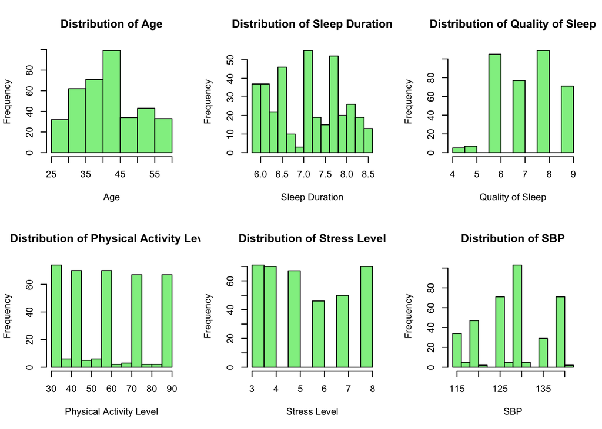

```r
# Check distributions
continuous <- c("Age", "Sleep Duration", "Quality of Sleep", "Physical Activity Level",
    "Stress Level", "SBP", "DBP", "PP", "Heart Rate", "Daily Steps")
par(mfrow = c(2, 3))
for (var in continuous) {
    hist(sleep[[var]], main = paste("Distribution of", var), xlab = var, col = "lightgreen",
        border = "black")
}
```

```r
sleep <- sleep %>%
    rename(age = Age, duration = `Sleep Duration`, quality = `Quality of Sleep`,
        pa = `Physical Activity Level`, stress = `Stress Level`, hr = `Heart Rate`,
        steps = `Daily Steps`) %>%
    dplyr::select(-Gender, -Occupation, -`BMI Category`, -`Sleep Disorder`)
```

[figure not shown]

All continuous variables look good. Quality of sleep and stress level are measured on a 0-10 scale and could potentially be used as categorical variables. However, with 374 observations, the sample size is not large enough to treat these variables as categorical. Therefore, in this project, they will be considered as continuous variables.

### Training/Validation/Testing Sets

```r
set.seed(12345)

# testing set (75%)
index.tr <- sample(1:nrow(sleep), size = nrow(sleep) * 0.75, replace = FALSE)
tr <- sleep[index.tr, ]

# validation set (25%)
val <- sleep[-index.tr, ]

# check dimensions
dim(sleep)
```

```
## [1] 374  15
```

```r
dim(tr)
```

```
## [1] 280  15
```

```r
dim(val)
```

```
## [1] 94 15
```

```r
# check proportions
nrow(tr)/nrow(sleep)
```

```
## [1] 0.7486631
```

```r
nrow(val)/nrow(sleep)
```

```
## [1] 0.2513369
```

### Summary

```r
skimr::skim(sleep)
```

Data summary

| Name | sleep |
| --- | --- |
| Number of rows | 374 |
| Number of columns | 15 |
| _______________________ |  |
| Column type frequency: |  |
| factor | 4 |
| numeric | 11 |
| ________________________ |  |
| Group variables | None |

**Variable type: factor**

| skim_variable | n_missing | complete_rate | ordered | n_unique | top_counts |
| --- | --- | --- | --- | --- | --- |
| gender_f | 0 | 1 | FALSE | 2 | Mal: 189, Fem: 185 |
| occup_f | 0 | 1 | FALSE | 2 | Non: 230, Med: 144 |
| bmi_f | 0 | 1 | FALSE | 2 | Nor: 216, Ove: 158 |
| disorder | 0 | 1 | FALSE | 3 | Non: 219, Sle: 78, Ins: 77 |

**Variable type: numeric**

| skim_variable | n_missing | complete_rate | mean | sd | p0 | p25 | p50 | p75 | p100 | hist |
| --- | --- | --- | --- | --- | --- | --- | --- | --- | --- | --- |
| age | 0 | 1 | 42.18 | 8.67 | 27.0 | 35.25 | 43.0 | 50.0 | 59.0 | ▆▆▇▃▅ |
| duration | 0 | 1 | 7.13 | 0.80 | 5.8 | 6.40 | 7.2 | 7.8 | 8.5 | ▇▆▇▇▆ |
| quality | 0 | 1 | 7.31 | 1.20 | 4.0 | 6.00 | 7.0 | 8.0 | 9.0 | ▁▇▆▇▅ |
| pa | 0 | 1 | 59.17 | 20.83 | 30.0 | 45.00 | 60.0 | 75.0 | 90.0 | ▇▇▇▇▇ |
| stress | 0 | 1 | 5.39 | 1.77 | 3.0 | 4.00 | 5.0 | 7.0 | 8.0 | ▇▃▂▃▃ |
| SBP | 0 | 1 | 128.55 | 7.75 | 115.0 | 125.00 | 130.0 | 135.0 | 142.0 | ▆▅▇▂▅ |
| DBP | 0 | 1 | 84.65 | 6.16 | 75.0 | 80.00 | 85.0 | 90.0 | 95.0 | ▃▇▇▂▅ |
| hr | 0 | 1 | 70.17 | 4.14 | 65.0 | 68.00 | 70.0 | 72.0 | 86.0 | ▇▇▂▁▁ |
| steps | 0 | 1 | 6816.84 | 1617.92 | 3000.0 | 5600.00 | 7000.0 | 8000.0 | 10000.0 | ▁▅▇▆▂ |
| PP | 0 | 1 | 43.90 | 2.26 | 37.0 | 43.00 | 45.0 | 45.0 | 50.0 | ▁▂▁▇▁ |
| htn | 0 | 1 | 0.18 | 0.39 | 0.0 | 0.00 | 0.0 | 0.0 | 1.0 | ▇▁▁▁▂ |

The variables seem to be coded appropriately: categorical variables are treated as factors, and the summary statistics confirm that continuous variables are coded as continuous.

**Gender:** Of 374 participants, 185 are female and 189 are male, showing a balanced gender split.

**Occupation:** After collapsing 11 occupations into two categories, 144 participants had medical-related jobs and 230 had non-medical jobs, leaving a clear imbalance favoring non-medical professions.

**Sleep Duration:** Ranges from 5.8–8.5 hours, with 7 hours most common, consistent with sleep guidelines.

**Sleep Quality:** Rated 4–9, mostly 6–9, indicating generally good quality, though a few rated 4–5.

**Physical Activity:** Ranges from 30–90 minutes/day, evenly distributed, reflecting diverse lifestyles.

**Stress Level:** Rated 3–8 on a 10-point scale, with many reporting 7–8, suggesting some higher stress levels.

**BMI:** Collapsed into “Normal” (216) vs. “Overweight/Obese” (158). Nearly half fall into the overweight/obese group, highlighting weight issues in this sample.

**Blood Pressure:** SBP 115–142 mmHg, DBP 75–95 mmHg. Most fall in normal to slightly elevated ranges, with 18% classified as hypertensive. Pulse Pressure is centered around 45 mmHg with a few outliers.

**Heart Rate:** Resting rates 65–86 bpm, mostly 65–75 bpm, suggesting overall cardiovascular health.

**Daily Steps:** 3,000–10,000 steps, peaking around 8,000, reflecting moderate activity.

**Sleep Disorder:** 219 reported no disorder, while 77 had Insomnia and 78 had Sleep Apnea.

## Sleep Disorder Prediction

### EDA

```r
# For continuous variables analysis
sleep_summary <- sleep %>%
  group_by(disorder) %>%
  summarize(
    avg_age = mean(age),
    median_age = median(age),
    sd_age = sd(age),
    iqr_age = IQR(age),
    range_age = max(age) - min(age),

    avg_SBP = mean(SBP),
    median_SBP = median(SBP),
    sd_SBP = sd(SBP),
    iqr_SBP = IQR(SBP),
    range_SBP = max(SBP) - min(SBP),

    avg_duration = mean(duration),
    median_duration = median(duration),
    sd_duration = sd(duration),
    iqr_duration = IQR(duration),
    range_duration = max(duration) - min(duration),

    avg_quality = mean(quality),
    median_quality = median(quality),
    sd_quality = sd(quality),
    iqr_quality = IQR(quality),
    range_quality = max(quality) - min(quality),

    avg_pa = mean(pa),
    median_pa = median(pa),
    sd_pa = sd(pa),
    iqr_pa = IQR(pa),
    range_pa = max(pa) - min(pa),

    avg_stress = mean(stress),
    median_stress = median(stress),
    sd_stress = sd(stress),
    iqr_stress = IQR(stress),
    range_stress = max(stress) - min(stress),

    avg_hr = mean(hr),
    median_hr = median(hr),
    sd_hr = sd(hr),
    iqr_hr = IQR(hr),
    range_hr = max(hr) - min(hr),

    avg_steps = mean(steps),
    median_steps = median(steps),
    sd_steps = sd(steps),
    iqr_steps = IQR(steps),
    range_steps = max(steps) - min(steps)
  )

# For Categorical variable analysis.
categorical_summary <- sleep %>%
  group_by(disorder) %>%
  summarize(
    count_female = sum(gender_f == "Female"),
    count_male = sum(gender_f == "Male"),
    count_medical = sum(occup_f == "Medical"),
    count_non_medical = sum(occup_f == "Non-medical"),
    count_normal_bmi = sum(bmi_f == "Normal"),
    count_overweight_obese = sum(bmi_f == "Overweight/Obese")
  )

# View summaries
print(sleep_summary)
```

```
## # A tibble: 3 × 41
##   disorder avg_age median_age sd_age iqr_age range_age avg_SBP median_SBP sd_SBP
##   <fct>      <dbl>      <dbl>  <dbl>   <dbl>     <dbl>   <dbl>      <dbl>  <dbl>
## 1 None        39.0         38   7.83   11           32    124.        125   5.73
## 2 Insomnia    43.5         44   4.81    2           25    132.        130   3.94
## 3 Sleep A…    49.7         50   8.99    8.75        31    138.        140   5.14
## # ℹ 32 more variables: iqr_SBP <dbl>, range_SBP <dbl>, avg_duration <dbl>,
## #   median_duration <dbl>, sd_duration <dbl>, iqr_duration <dbl>,
## #   range_duration <dbl>, avg_quality <dbl>, median_quality <dbl>,
## #   sd_quality <dbl>, iqr_quality <dbl>, range_quality <dbl>, avg_pa <dbl>,
## #   median_pa <dbl>, sd_pa <dbl>, iqr_pa <dbl>, range_pa <dbl>,
## #   avg_stress <dbl>, median_stress <dbl>, sd_stress <dbl>, iqr_stress <dbl>,
## #   range_stress <dbl>, avg_hr <dbl>, median_hr <dbl>, sd_hr <dbl>, …
```

```r
print(categorical_summary)
```

```
## # A tibble: 3 × 7
##   disorder    count_female count_male count_medical count_non_medical
##   <fct>              <int>      <int>         <int>             <int>
## 1 None                  82        137            73               146
## 2 Insomnia              36         41             6                71
## 3 Sleep Apnea           67         11            65                13
## # ℹ 2 more variables: count_normal_bmi <int>, count_overweight_obese <int>
```

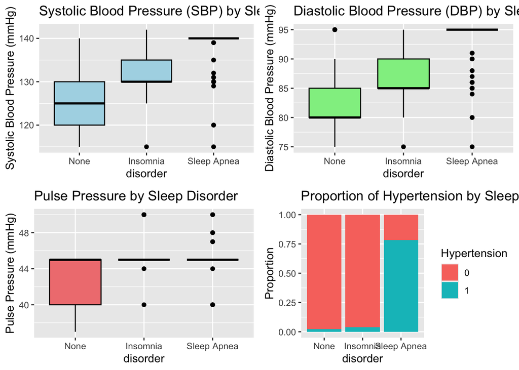

```r
############### Exploratory graphic data analysis ###############

# Grouped by sleep disorder
p1 <- ggplot(sleep, aes(x = disorder, y = SBP)) +
  geom_boxplot(fill = "lightblue", color = "black") +
  labs(title = "Systolic Blood Pressure (SBP) by Sleep Disorder", y = "Systolic Blood Pressure (mmHg)")

p2 <- ggplot(sleep, aes(x = disorder, y = DBP)) +
  geom_boxplot(fill = "lightgreen", color = "black") +
  labs(title = "Diastolic Blood Pressure (DBP) by Sleep Disorder", y = "Diastolic Blood Pressure (mmHg)")

p3 <- ggplot(sleep, aes(x = disorder, y = PP)) +
  geom_boxplot(fill = "lightcoral", color = "black") +
  labs(title = "Pulse Pressure by Sleep Disorder", y = "Pulse Pressure (mmHg)")

p4 <- ggplot(sleep, aes(x = disorder, fill = factor(htn))) +
  geom_bar(position = "fill") +
  labs(title = "Proportion of Hypertension by Sleep Disorder", y = "Proportion", fill = "Hypertension")

# Combine all plots into a 2x2 grid
grid.arrange(p1, p2, p3, p4, ncol = 2)
```

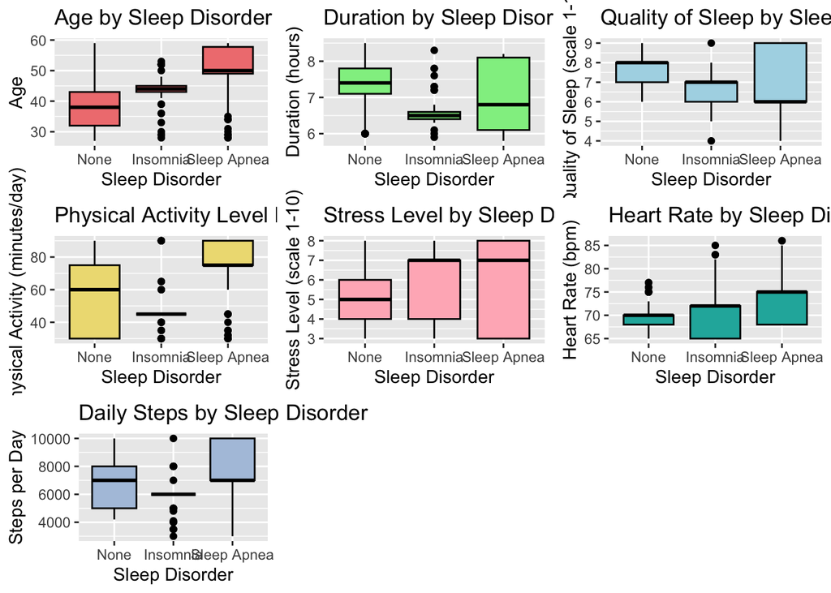

```r
# For other continuous variables
# For age
c1 <- ggplot(sleep, aes(x = disorder, y = age)) +
  geom_boxplot(fill = "lightcoral", color = "black") +
  labs(title = "Age by Sleep Disorder", x = "Sleep Disorder", y = "Age")

# For duration
c2 <- ggplot(sleep, aes(x = disorder, y = duration)) +
  geom_boxplot(fill = "lightgreen", color = "black") +
  labs(title = "Duration by Sleep Disorder", x = "Sleep Disorder", y = "Duration (hours)")

# For quality
c3 <- ggplot(sleep, aes(x = disorder, y = quality)) +
  geom_boxplot(fill = "lightblue", color = "black") +
  labs(title = "Quality of Sleep by Sleep Disorder", x = "Sleep Disorder", y = "Quality of Sleep (scale 1-10)")

# For physical activity level
c4 <- ggplot(sleep, aes(x = disorder, y = pa)) +
  geom_boxplot(fill = "lightgoldenrod", color = "black") +
  labs(title = "Physical Activity Level by Sleep Disorder", x = "Sleep Disorder", y = "Physical Activity (minutes/day)")

# For stress level
c5 <- ggplot(sleep, aes(x = disorder, y = stress)) +
  geom_boxplot(fill = "lightpink", color = "black") +
  labs(title = "Stress Level by Sleep Disorder", x = "Sleep Disorder", y = "Stress Level (scale 1-10)")

# For heart rate
c6 <- ggplot(sleep, aes(x = disorder, y = hr)) +
  geom_boxplot(fill = "lightseagreen", color = "black") +
  labs(title = "Heart Rate by Sleep Disorder", x = "Sleep Disorder", y = "Heart Rate (bpm)")

# For daily steps
c7 <- ggplot(sleep, aes(x = disorder, y = steps)) +
  geom_boxplot(fill = "lightsteelblue", color = "black") +
  labs(title = "Daily Steps by Sleep Disorder", x = "Sleep Disorder", y = "Steps per Day")

grid.arrange(c1, c2, c3, c4, c5, c6, c7, ncol = 3)
```

**Comment:**

**PP:** Median pulse pressure shows little difference among the three groups. Although there are small variations, the distributions overlap substantially, suggesting that pulse pressure is not a strong factor distinguishing these groups.

**Hypertension:** The prevalence of hypertension is much higher among individuals with Sleep Apnea, affecting nearly three-quarters of the group. In comparison, fewer participants with Insomnia or without sleep disorders are hypertensive, and the lowest proportion is observed in the group with no disorder. This emphasizes the strong link between Sleep Apnea and hypertension.

**Age:** Sleep Apnea is more common among older participants, with a median age above 50 years. Participants with Insomnia are somewhat younger, while those without a sleep disorder are the youngest, with a median age around 40 years. This suggests that Sleep Apnea is particularly prevalent in older adults.

**Stress Level:** Stress levels are higher among participants with Insomnia and Sleep Apnea, with medians of about 6 to 7. Those without a sleep disorder report lower stress, with a median of about 5. This supports the connection between sleep disturbances and higher stress.

**Heart Rate:** Participants with Sleep Apnea have slightly higher resting heart rates, with a median of about 75 beats per minute. Those without a sleep disorder have a lower median of about 70 beats per minute, and Insomnia participants fall in between. Elevated heart rate is consistent with the cardiovascular risks linked to Sleep Apnea.

### ML Analyses

#### Categorical variables modeling

During data cleaning, categorical variables such as gender, occupation, and BMI were converted into binary factors, which is appropriate for applying LDA, QDA, Naive Bayes, and multinomial logistic regression models. The outcome variable, sleep disorders, was coded as a factor with three categories. Other potential categorical variables, including quality of sleep and stress level, were treated as continuous variables and maintained in numeric form.

#### LDA

```r
library(MASS)
library(caret)

######## PP ########
set.seed(1003)
lda.pp <- lda(disorder ~ PP + gender_f + age + occup_f + duration + quality + pa +
    stress + bmi_f + hr + steps, data = tr)

pred.lda.pp <- predict(lda.pp, newdata = val)$class
conf.lda.pp <- confusionMatrix(pred.lda.pp, val$disorder)
print(conf.lda.pp)
```

```
## Confusion Matrix and Statistics
##
##              Reference
## Prediction    None Insomnia Sleep Apnea
##   None          44        1           2
##   Insomnia       4       20           0
##   Sleep Apnea    3        0          20
##
## Overall Statistics
##
##                Accuracy : 0.8936
##                  95% CI : (0.813, 0.9478)
##     No Information Rate : 0.5426
##     P-Value [Acc > NIR] : 2.074e-13
##
##                   Kappa : 0.8269
##
##  Mcnemar's Test P-Value : NA
##
## Statistics by Class:
##
##                      Class: None Class: Insomnia Class: Sleep Apnea
## Sensitivity               0.8627          0.9524             0.9091
## Specificity               0.9302          0.9452             0.9583
## Pos Pred Value            0.9362          0.8333             0.8696
## Neg Pred Value            0.8511          0.9857             0.9718
## Prevalence                0.5426          0.2234             0.2340
## Detection Rate            0.4681          0.2128             0.2128
## Detection Prevalence      0.5000          0.2553             0.2447
## Balanced Accuracy         0.8965          0.9488             0.9337
```

```r
# Accuracy, Sensitivity, Specificity
print(lda.pp.acc <- conf.lda.pp$overall["Accuracy"])
```

```
## Accuracy
## 0.893617
```

```r
print(lda.pp.sens <- conf.lda.pp$byClass[, "Sensitivity"])
```

```
##        Class: None    Class: Insomnia Class: Sleep Apnea
##          0.8627451          0.9523810          0.9090909
```

```r
print(lda.pp.spec <- conf.lda.pp$byClass[, "Specificity"])
```

```
##        Class: None    Class: Insomnia Class: Sleep Apnea
##          0.9302326          0.9452055          0.9583333
```

```r
######## HTN ########
set.seed(1003)
lda.htn <- lda(disorder ~ htn + gender_f + age + occup_f + duration + quality + pa +
    stress + bmi_f + hr + steps, data = tr)

pred.lda.htn <- predict(lda.htn, newdata = val)$class
conf.lda.htn <- confusionMatrix(pred.lda.htn, val$disorder)
print(conf.lda.htn)
```

```
## Confusion Matrix and Statistics
##
##              Reference
## Prediction    None Insomnia Sleep Apnea
##   None          44        1           2
##   Insomnia       5       19           0
##   Sleep Apnea    2        1          20
##
## Overall Statistics
##
##                Accuracy : 0.883
##                  95% CI : (0.8003, 0.9401)
##     No Information Rate : 0.5426
##     P-Value [Acc > NIR] : 1.36e-12
##
##                   Kappa : 0.8095
##
##  Mcnemar's Test P-Value : 0.2998
##
## Statistics by Class:
##
##                      Class: None Class: Insomnia Class: Sleep Apnea
## Sensitivity               0.8627          0.9048             0.9091
## Specificity               0.9302          0.9315             0.9583
## Pos Pred Value            0.9362          0.7917             0.8696
## Neg Pred Value            0.8511          0.9714             0.9718
## Prevalence                0.5426          0.2234             0.2340
## Detection Rate            0.4681          0.2021             0.2128
## Detection Prevalence      0.5000          0.2553             0.2447
## Balanced Accuracy         0.8965          0.9181             0.9337
```

```r
# Accuracy, Sensitivity, Specificity
print(lda.htn.acc <- conf.lda.htn$overall["Accuracy"])
```

```
##  Accuracy
## 0.8829787
```

```r
print(lda.htn.sens <- conf.lda.htn$byClass[, "Sensitivity"])
```

```
##        Class: None    Class: Insomnia Class: Sleep Apnea
##          0.8627451          0.9047619          0.9090909
```

```r
print(lda.htn.spec <- conf.lda.htn$byClass[, "Specificity"])
```

```
##        Class: None    Class: Insomnia Class: Sleep Apnea
##          0.9302326          0.9315068          0.9583333
```

#### QDA

```r
######## PP ########
set.seed(1003)
qda.pp <- qda(disorder ~ PP + gender_f + age + occup_f + duration + quality + pa +
    stress + bmi_f + hr + steps, data = tr)

pred.qda.pp <- predict(qda.pp, newdata = val)$class
conf.qda.pp <- confusionMatrix(pred.qda.pp, val$disorder)
print(conf.qda.pp)
```

```
## Confusion Matrix and Statistics
##
##              Reference
## Prediction    None Insomnia Sleep Apnea
##   None          45        1           2
##   Insomnia       4       19           0
##   Sleep Apnea    2        1          20
##
## Overall Statistics
##
##                Accuracy : 0.8936
##                  95% CI : (0.813, 0.9478)
##     No Information Rate : 0.5426
##     P-Value [Acc > NIR] : 2.074e-13
##
##                   Kappa : 0.8259
##
##  Mcnemar's Test P-Value : 0.4235
##
## Statistics by Class:
##
##                      Class: None Class: Insomnia Class: Sleep Apnea
## Sensitivity               0.8824          0.9048             0.9091
## Specificity               0.9302          0.9452             0.9583
## Pos Pred Value            0.9375          0.8261             0.8696
## Neg Pred Value            0.8696          0.9718             0.9718
## Prevalence                0.5426          0.2234             0.2340
## Detection Rate            0.4787          0.2021             0.2128
## Detection Prevalence      0.5106          0.2447             0.2447
## Balanced Accuracy         0.9063          0.9250             0.9337
```

```r
# Accuracy, Sensitivity, Specificity
print(qda.pp.acc <- conf.qda.pp$overall["Accuracy"])
```

```
## Accuracy
## 0.893617
```

```r
print(qda.pp.sens <- conf.qda.pp$byClass[, "Sensitivity"])
```

```
##        Class: None    Class: Insomnia Class: Sleep Apnea
##          0.8823529          0.9047619          0.9090909
```

```r
print(qda.pp.spec <- conf.qda.pp$byClass[, "Specificity"])
```

```
##        Class: None    Class: Insomnia Class: Sleep Apnea
##          0.9302326          0.9452055          0.9583333
```

```r
######## HTN ########
set.seed(1003)
qda.htn <- qda(disorder ~ htn + gender_f + age + occup_f + duration + quality + pa +
    stress + bmi_f + hr + steps, data = tr)

pred.qda.htn <- predict(qda.htn, newdata = val)$class
conf.qda.htn <- confusionMatrix(pred.qda.htn, val$disorder)
print(conf.qda.htn)
```

```
## Confusion Matrix and Statistics
##
##              Reference
## Prediction    None Insomnia Sleep Apnea
##   None          47        1           2
##   Insomnia       2       19           0
##   Sleep Apnea    2        1          20
##
## Overall Statistics
##
##                Accuracy : 0.9149
##                  95% CI : (0.8392, 0.9625)
##     No Information Rate : 0.5426
##     P-Value [Acc > NIR] : 3.472e-15
##
##                   Kappa : 0.8591
##
##  Mcnemar's Test P-Value : 0.7212
##
## Statistics by Class:
##
##                      Class: None Class: Insomnia Class: Sleep Apnea
## Sensitivity               0.9216          0.9048             0.9091
## Specificity               0.9302          0.9726             0.9583
## Pos Pred Value            0.9400          0.9048             0.8696
## Neg Pred Value            0.9091          0.9726             0.9718
## Prevalence                0.5426          0.2234             0.2340
## Detection Rate            0.5000          0.2021             0.2128
## Detection Prevalence      0.5319          0.2234             0.2447
## Balanced Accuracy         0.9259          0.9387             0.9337
```

```r
# Accuracy, Sensitivity, Specificity
print(qda.htn.acc <- conf.qda.htn$overall["Accuracy"])
```

```
##  Accuracy
## 0.9148936
```

```r
print(qda.htn.sens <- conf.qda.htn$byClass[, "Sensitivity"])
```

```
##        Class: None    Class: Insomnia Class: Sleep Apnea
##          0.9215686          0.9047619          0.9090909
```

```r
print(qda.htn.spec <- conf.qda.htn$byClass[, "Specificity"])
```

```
##        Class: None    Class: Insomnia Class: Sleep Apnea
##          0.9302326          0.9726027          0.9583333
```

#### Naive Bayes

```r
library(naivebayes)
######## PP ########
set.seed(1003)
nb.pp <- naive_bayes(disorder ~ PP + gender_f + age + occup_f + duration + quality +
    pa + stress + bmi_f + hr + steps, data = tr)

pred.nb.pp <- predict(nb.pp, newdata = val)
conf.nb.pp <- confusionMatrix(pred.nb.pp, val$disorder)
print(conf.nb.pp)
```

```
## Confusion Matrix and Statistics
##
##              Reference
## Prediction    None Insomnia Sleep Apnea
##   None          43        1           2
##   Insomnia       6       19           0
##   Sleep Apnea    2        1          20
##
## Overall Statistics
##
##                Accuracy : 0.8723
##                  95% CI : (0.7876, 0.9323)
##     No Information Rate : 0.5426
##     P-Value [Acc > NIR] : 8.08e-12
##
##                   Kappa : 0.7934
##
##  Mcnemar's Test P-Value : 0.206
##
## Statistics by Class:
##
##                      Class: None Class: Insomnia Class: Sleep Apnea
## Sensitivity               0.8431          0.9048             0.9091
## Specificity               0.9302          0.9178             0.9583
## Pos Pred Value            0.9348          0.7600             0.8696
## Neg Pred Value            0.8333          0.9710             0.9718
## Prevalence                0.5426          0.2234             0.2340
## Detection Rate            0.4574          0.2021             0.2128
## Detection Prevalence      0.4894          0.2660             0.2447
## Balanced Accuracy         0.8867          0.9113             0.9337
```

```r
# Accuracy, Sensitivity, Specificity
print(nb.pp.acc <- conf.nb.pp$overall["Accuracy"])
```

```
##  Accuracy
## 0.8723404
```

```r
print(nb.pp.sens <- conf.nb.pp$byClass[, "Sensitivity"])
```

```
##        Class: None    Class: Insomnia Class: Sleep Apnea
##          0.8431373          0.9047619          0.9090909
```

```r
print(nb.pp.spec <- conf.nb.pp$byClass[, "Specificity"])
```

```
##        Class: None    Class: Insomnia Class: Sleep Apnea
##          0.9302326          0.9178082          0.9583333
```

```r
######## HTN ########
set.seed(1003)
nb.htn <- naive_bayes(disorder ~ htn + gender_f + age + occup_f + duration + quality +
    pa + stress + bmi_f + hr + steps, data = tr)

pred.nb.htn <- predict(nb.htn, newdata = val)
conf.nb.htn <- confusionMatrix(pred.nb.htn, val$disorder)
print(conf.nb.htn)
```

```
## Confusion Matrix and Statistics
##
##              Reference
## Prediction    None Insomnia Sleep Apnea
##   None          43        1           2
##   Insomnia       6       19           0
##   Sleep Apnea    2        1          20
##
## Overall Statistics
##
##                Accuracy : 0.8723
##                  95% CI : (0.7876, 0.9323)
##     No Information Rate : 0.5426
##     P-Value [Acc > NIR] : 8.08e-12
##
##                   Kappa : 0.7934
##
##  Mcnemar's Test P-Value : 0.206
##
## Statistics by Class:
##
##                      Class: None Class: Insomnia Class: Sleep Apnea
## Sensitivity               0.8431          0.9048             0.9091
## Specificity               0.9302          0.9178             0.9583
## Pos Pred Value            0.9348          0.7600             0.8696
## Neg Pred Value            0.8333          0.9710             0.9718
## Prevalence                0.5426          0.2234             0.2340
## Detection Rate            0.4574          0.2021             0.2128
## Detection Prevalence      0.4894          0.2660             0.2447
## Balanced Accuracy         0.8867          0.9113             0.9337
```

```r
# Accuracy, Sensitivity, Specificity
print(nb.htn.acc <- conf.nb.htn$overall["Accuracy"])
```

```
##  Accuracy
## 0.8723404
```

```r
print(nb.htn.sens <- conf.nb.htn$byClass[, "Sensitivity"])
```

```
##        Class: None    Class: Insomnia Class: Sleep Apnea
##          0.8431373          0.9047619          0.9090909
```

```r
print(nb.htn.spec <- conf.nb.htn$byClass[, "Specificity"])
```

```
##        Class: None    Class: Insomnia Class: Sleep Apnea
##          0.9302326          0.9178082          0.9583333
```

#### Multinomial Logistic

```r
library(nnet)

######## PP ########
set.seed(1003)
mnr.pp <- multinom(disorder ~ PP + gender_f + age + occup_f + duration + quality +
    pa + stress + bmi_f + hr + steps, data = tr)
pred.mnr.pp <- predict(mnr.pp, newdata = val)
conf.mnr.pp <- confusionMatrix(pred.mnr.pp, val$disorder)
print(conf.mnr.pp)
```

```
## Confusion Matrix and Statistics
##
##              Reference
## Prediction    None Insomnia Sleep Apnea
##   None          46        1           2
##   Insomnia       1       20           0
##   Sleep Apnea    4        0          20
##
## Overall Statistics
##
##                Accuracy : 0.9149
##                  95% CI : (0.8392, 0.9625)
##     No Information Rate : 0.5426
##     P-Value [Acc > NIR] : 3.472e-15
##
##                   Kappa : 0.8599
##
##  Mcnemar's Test P-Value : NA
##
## Statistics by Class:
##
##                      Class: None Class: Insomnia Class: Sleep Apnea
## Sensitivity               0.9020          0.9524             0.9091
## Specificity               0.9302          0.9863             0.9444
## Pos Pred Value            0.9388          0.9524             0.8333
## Neg Pred Value            0.8889          0.9863             0.9714
## Prevalence                0.5426          0.2234             0.2340
## Detection Rate            0.4894          0.2128             0.2128
## Detection Prevalence      0.5213          0.2234             0.2553
## Balanced Accuracy         0.9161          0.9693             0.9268
```

```r
# Accuracy, Sensitivity, Specificity
print(mnr.pp.acc <- conf.mnr.pp$overall["Accuracy"])
```

```
##  Accuracy
## 0.9148936
```

```r
print(mnr.pp.sens <- conf.mnr.pp$byClass[, "Sensitivity"])
```

```
##        Class: None    Class: Insomnia Class: Sleep Apnea
##          0.9019608          0.9523810          0.9090909
```

```r
print(mnr.pp.spec <- conf.mnr.pp$byClass[, "Specificity"])
```

```
##        Class: None    Class: Insomnia Class: Sleep Apnea
##          0.9302326          0.9863014          0.9444444
```

```r
######## HTN ########
set.seed(1003)
mnr.htn <- multinom(disorder ~ htn + gender_f + age + occup_f + duration + quality +
    pa + stress + bmi_f + hr + steps, data = tr)
pred.mnr.htn <- predict(mnr.htn, newdata = val)
conf.mnr.htn <- confusionMatrix(pred.mnr.htn, val$disorder)
print(conf.mnr.htn)
```

```
## Confusion Matrix and Statistics
##
##              Reference
## Prediction    None Insomnia Sleep Apnea
##   None          45        1           2
##   Insomnia       3       19           0
##   Sleep Apnea    3        1          20
##
## Overall Statistics
##
##                Accuracy : 0.8936
##                  95% CI : (0.813, 0.9478)
##     No Information Rate : 0.5426
##     P-Value [Acc > NIR] : 2.074e-13
##
##                   Kappa : 0.8259
##
##  Mcnemar's Test P-Value : 0.5319
##
## Statistics by Class:
##
##                      Class: None Class: Insomnia Class: Sleep Apnea
## Sensitivity               0.8824          0.9048             0.9091
## Specificity               0.9302          0.9589             0.9444
## Pos Pred Value            0.9375          0.8636             0.8333
## Neg Pred Value            0.8696          0.9722             0.9714
## Prevalence                0.5426          0.2234             0.2340
## Detection Rate            0.4787          0.2021             0.2128
## Detection Prevalence      0.5106          0.2340             0.2553
## Balanced Accuracy         0.9063          0.9318             0.9268
```

```r
# Accuracy, Sensitivity, Specificity
print(mnr.htn.acc <- conf.mnr.htn$overall["Accuracy"])
```

```
## Accuracy
## 0.893617
```

```r
print(mnr.htn.sens <- conf.mnr.htn$byClass[, "Sensitivity"])
```

```
##        Class: None    Class: Insomnia Class: Sleep Apnea
##          0.8823529          0.9047619          0.9090909
```

```r
print(mnr.htn.spec <- conf.mnr.htn$byClass[, "Specificity"])
```

```
##        Class: None    Class: Insomnia Class: Sleep Apnea
##          0.9302326          0.9589041          0.9444444
```

#### Table

```r
# Create results data frame
results <- data.frame(Method = c("LDA", "LDA", "QDA", "QDA", "Naive Bayes", "Naive Bayes",
    "Multinomial Logistic", "Multinomial Logistic"), BP_Var = c("PP", "HTN", "PP",
    "HTN", "PP", "HTN", "PP", "HTN"), Accuracy = c(lda.pp.acc, lda.htn.acc, qda.pp.acc,
    qda.htn.acc, nb.pp.acc, nb.htn.acc, mnr.pp.acc, mnr.htn.acc), Sens1 = c(lda.pp.sens[1],
    lda.htn.sens[1], qda.pp.sens[1], qda.htn.sens[1], nb.pp.sens[1], nb.htn.sens[1],
    mnr.pp.sens[1], mnr.htn.sens[1]), Sens2 = c(lda.pp.sens[2], lda.htn.sens[2],
    qda.pp.sens[2], qda.htn.sens[2], nb.pp.sens[2], nb.htn.sens[2], mnr.pp.sens[2],
    mnr.htn.sens[2]), Sens3 = c(lda.pp.sens[3], lda.htn.sens[3], qda.pp.sens[3],
    qda.htn.sens[3], nb.pp.sens[3], nb.htn.sens[3], mnr.pp.sens[3], mnr.htn.sens[3]),
    Spec1 = c(lda.pp.spec[1], lda.htn.spec[1], qda.pp.spec[1], qda.htn.spec[1], nb.pp.spec[1],
        nb.htn.spec[1], mnr.pp.spec[1], mnr.htn.spec[1]), Spec2 = c(lda.pp.spec[2],
        lda.htn.spec[2], qda.pp.spec[2], qda.htn.spec[2], nb.pp.spec[2], nb.htn.spec[2],
        mnr.pp.spec[2], mnr.htn.spec[2]), Spec3 = c(lda.pp.spec[3], lda.htn.spec[3],
        qda.pp.spec[3], qda.htn.spec[3], nb.pp.spec[3], nb.htn.spec[3], mnr.pp.spec[3],
        mnr.htn.spec[3]))

print(results)
```

```
##                 Method BP_Var  Accuracy     Sens1     Sens2     Sens3     Spec1
## 1                  LDA     PP 0.8936170 0.8627451 0.9523810 0.9090909 0.9302326
## 2                  LDA    HTN 0.8829787 0.8627451 0.9047619 0.9090909 0.9302326
## 3                  QDA     PP 0.8936170 0.8823529 0.9047619 0.9090909 0.9302326
## 4                  QDA    HTN 0.9148936 0.9215686 0.9047619 0.9090909 0.9302326
## 5          Naive Bayes     PP 0.8723404 0.8431373 0.9047619 0.9090909 0.9302326
## 6          Naive Bayes    HTN 0.8723404 0.8431373 0.9047619 0.9090909 0.9302326
## 7 Multinomial Logistic     PP 0.9148936 0.9019608 0.9523810 0.9090909 0.9302326
## 8 Multinomial Logistic    HTN 0.8936170 0.8823529 0.9047619 0.9090909 0.9302326
##       Spec2     Spec3
## 1 0.9452055 0.9583333
## 2 0.9315068 0.9583333
## 3 0.9452055 0.9583333
## 4 0.9726027 0.9583333
## 5 0.9178082 0.9583333
## 6 0.9178082 0.9583333
## 7 0.9863014 0.9444444
## 8 0.9589041 0.9444444
```

| Method | SPB Variable | Accuracy | Sens 1 | Sens 2 | Sens 3 | Spec 1 | Spec 2 | Spec 3 |
| --- | --- | --- | --- | --- | --- | --- | --- | --- |
| LDA | PP | 0.8936 | 0.8627 | 0.9524 | 0.9091 | 0.9302 | 0.9452 | 0.9583 |
|  | HTN | 0.8830 | 0.8627 | 0.9048 | 0.9091 | 0.9302 | 0.9315 | 0.9583 |
| QDA | PP | 0.8936 | 0.8824 | 0.9048 | 0.9091 | 0.9302 | 0.9452 | 0.9583 |
|  | HTN | 0.9149 | 0.9216 | 0.9048 | 0.9091 | 0.9302 | 0.9726 | 0.9583 |
| Naive Bayes | PP | 0.8723 | 0.8431 | 0.9048 | 0.9091 | 0.9302 | 0.9178 | 0.9583 |
|  | HTN | 0.8723 | 0.8431 | 0.9048 | 0.9091 | 0.9302 | 0.9178 | 0.9583 |
| Multonomial Logistic | PP | 0.9149 | 0.9020 | 0.9524 | 0.9091 | 0.9302 | 0.9863 | 0.9444 |
|  | HTN | 0.8936 | 0.8824 | 0.9048 | 0.9091 | 0.9302 | 0.9589 | 0.9444 |

### Interpretation

#### Blood Pressure Parameterization

Based on the validation results, the preferred blood pressure parameterization varied by model.  
For LDA, the model using pulse pressure (PP) showed slightly higher accuracy compared to the HTN version.  
For QDA, the HTN-based model outperformed PP, achieving the highest overall accuracy among all models.  
For Naive Bayes, the performance was essentially identical between PP and HTN.  
For Multinomial Logistic regression, the PP version provided better accuracy and specificity than the HTN version.

The preferred parameterization varies by model. For LDA and Multinomial Logistic Regression, pulse pressure (PP) produced higher accuracy than HTN, whereas for QDA the HTN version performed better. For Naive Bayes, both parameterizations yielded identical performance.

If I had to recommend one parameterization overall, pulse pressure (PP) would be preferred. This is because PP performed better in two of the four models (LDA and Multinomial Logistic), tied in one model (Naive Bayes), and was only outperformed by HTN in QDA. Moreover, PP provides more continuous variation and may capture subtler differences across groups compared to a binary HTN indicator.

```r
# Re-check distributions of PP and HTN by sleep disorder
aggregate(PP ~ disorder, data = sleep, mean)
```

```
##      disorder       PP
## 1        None 43.04566
## 2    Insomnia 45.18182
## 3 Sleep Apnea 45.05128
```

```r
aggregate(htn ~ disorder, data = sleep, mean)
```

```
##      disorder        htn
## 1        None 0.02283105
## 2    Insomnia 0.03896104
## 3 Sleep Apnea 0.78205128
```

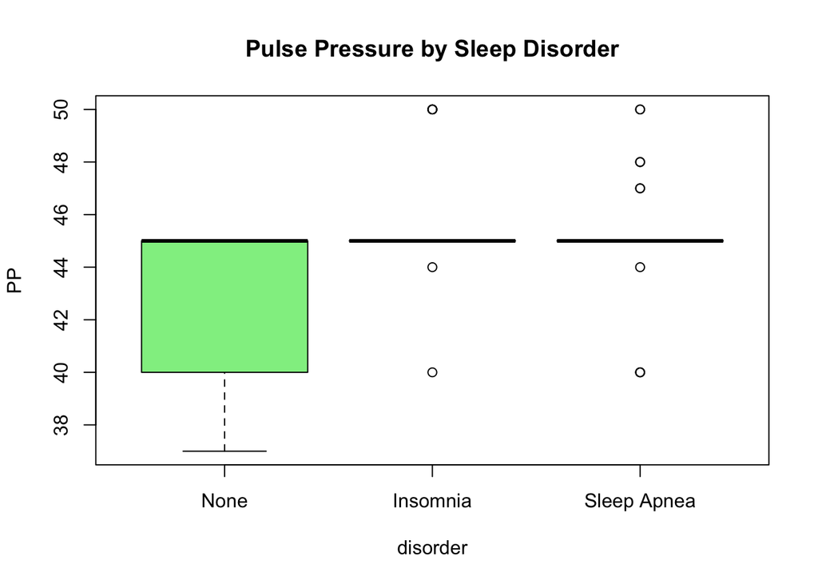

```r
# Or boxplot/prop plot again
boxplot(PP ~ disorder, data = sleep, main = "Pulse Pressure by Sleep Disorder", col = "lightgreen")
```

```r
prop.table(table(sleep$disorder, sleep$htn), 1)
```

```
##
##                        0          1
##   None        0.97716895 0.02283105
##   Insomnia    0.96103896 0.03896104
##   Sleep Apnea 0.21794872 0.78205128
```

The exploratory analysis in part 1 showed that pulse pressure (PP) did not differ much across sleep disorder groups, while hypertension (HTN) was clearly more common among individuals with Sleep Apnea. The modeling results are mostly consistent with this observation: HTN performed well in QDA, reflecting its strong univariate association with Sleep Apnea, but PP provided better or equally good accuracy in other models by capturing more continuous variation. Together, this suggests that although HTN is a strong simple indicator, PP may add more flexibility and predictive value in multivariate settings.

#### Risk determination

##### Model selection

```r
# Compare overall accuracy for all models to identify the best for prediction
acc_values <- data.frame(Method = c("LDA_PP", "LDA_HTN", "QDA_PP", "QDA_HTN", "NB_PP",
    "NB_HTN", "MNR_PP", "MNR_HTN"), Accuracy = c(lda.pp.acc, lda.htn.acc, qda.pp.acc,
    qda.htn.acc, nb.pp.acc, nb.htn.acc, mnr.pp.acc, mnr.htn.acc))

print(acc_values)
```

```
##    Method  Accuracy
## 1  LDA_PP 0.8936170
## 2 LDA_HTN 0.8829787
## 3  QDA_PP 0.8936170
## 4 QDA_HTN 0.9148936
## 5   NB_PP 0.8723404
## 6  NB_HTN 0.8723404
## 7  MNR_PP 0.9148936
## 8 MNR_HTN 0.8936170
```

```r
# Identify the best-performing model
best_model <- acc_values[which.max(acc_values$Accuracy), ]
print(best_model)
```

```
##    Method  Accuracy
## 4 QDA_HTN 0.9148936
```

```r
probs.mnr.pp <- predict(mnr.pp, newdata = val, type = "prob")
head(probs.mnr.pp)  # show predicted risks for each class
```

```
##          None     Insomnia Sleep Apnea
## 1 0.005823415 7.025301e-01  0.29164650
## 2 0.976907138 1.025169e-04  0.02299034
## 3 0.959800457 2.882695e-05  0.04017072
## 4 0.959800457 2.882695e-05  0.04017072
## 5 0.959800457 2.882695e-05  0.04017072
## 6 0.959800457 2.882695e-05  0.04017072
```

**Comment:** For the purpose of estimating patient risk in a clinical setting, the most appropriate model is the multinomial logistic regression with pulse pressure (PP). This model achieved one of the highest overall accuracies and, importantly, provides predicted probabilities for each outcome category (None, Insomnia, Sleep Apnea). These probabilities can be directly interpreted as a patient’s estimated risk of each type of sleep disorder, which is exactly what a clinician would need when evaluating patients. While QDA with HTN also performed well in terms of accuracy, multinomial logistic regression is more interpretable and yields clinically useful risk estimates.

##### Final accuracy, sensitivity, specificity

```r
# Final chosen model performance
print(mnr.pp.acc)
```

```
##  Accuracy
## 0.9148936
```

```r
print(mnr.pp.sens)
```

```
##        Class: None    Class: Insomnia Class: Sleep Apnea
##          0.9019608          0.9523810          0.9090909
```

```r
print(mnr.pp.spec)
```

```
##        Class: None    Class: Insomnia Class: Sleep Apnea
##          0.9302326          0.9863014          0.9444444
```

**Comment:** For the final model (Multinomial Logistic Regression with PP), the validation set accuracy was approximately 0.915. Sensitivity values across the three classes ranged from about 0.90 to 0.95, and specificity values were all above 0.93. These metrics indicate that the model performs consistently well in correctly identifying each sleep disorder category as well as distinguishing patients without the condition.

##### Explanation for a practitioner

The final model we selected was a multinomial logistic regression using pulse pressure (PP) and other patient predictors including gender, age, occupation, sleep duration, sleep quality, physical activity, BMI, stress, heart rate, and daily steps. The model achieved an overall accuracy of about 91%, which means it correctly classified sleep disorders in roughly 91 out of 100 patients.

In terms of sensitivity, the model was able to detect patients with no disorder, insomnia, and sleep apnea at rates around 90–95%, while also maintaining high specificity above 93% across all categories. For example, this means the model is very unlikely to miss patients with sleep apnea and also rarely misclassifies patients who do not have a disorder.

From a clinical perspective, the most important feature of this model is that it provides estimated probabilities for each diagnosis. For a given patient, the clinician can see the likelihood of no disorder, insomnia, or sleep apnea, and use that information to guide further diagnostic testing and treatment decisions. In practice, this model serves as a reliable tool to support risk assessment in a sleep clinic, helping to prioritize patients who are most likely to benefit from further evaluation and intervention.

#### Sleep disorders

##### Model selected

```r
# Multinomial logistic regression with PP
summary(mnr.pp)  # coefficients, standard errors, significance
```

```
## Call:
## multinom(formula = disorder ~ PP + gender_f + age + occup_f +
##     duration + quality + pa + stress + bmi_f + hr + steps, data = tr)
##
## Coefficients:
##             (Intercept)        PP gender_fMale          age occup_fNon-medical
## Insomnia       8.973737 0.2972990    -1.097796  0.276905625           2.753062
## Sleep Apnea  -49.420217 0.1346206    -2.506103 -0.006158044          -1.271592
##              duration   quality          pa     stress bmi_fOverweight/Obese
## Insomnia    -2.465374 -1.282352  0.09830117  0.1157415            -0.1396351
## Sleep Apnea  2.483685 -1.061831 -0.07170841 -0.1999819             4.9899308
##                      hr        steps
## Insomnia    -0.09746962 -0.001409935
## Sleep Apnea  0.42007368  0.001067152
##
## Std. Errors:
##             (Intercept)        PP gender_fMale        age occup_fNon-medical
## Insomnia    0.002862379 0.1155889   0.01467093 0.04709599        0.016792092
## Sleep Apnea 0.003217650 0.1576335   0.01997328 0.06067418        0.006241576
##               duration    quality         pa     stress bmi_fOverweight/Obese
## Insomnia    0.06140181 0.08670288 0.02133724 0.07206161            0.03609671
## Sleep Apnea 0.07557149 0.10406818 0.02643218 0.10966090            0.02338863
##                     hr        steps
## Insomnia    0.06149314 0.0003225057
## Sleep Apnea 0.07705656 0.0002452241
##
## Residual Deviance: 193.7189
## AIC: 241.7189
```

**Comment:** For examining relationships, I would use the multinomial logistic regression model with pulse pressure (PP). This model provides interpretable coefficients and statistical significance tests, which allow us to see how each variable is associated with the likelihood of having insomnia or sleep apnea compared with no disorder. Unlike LDA, QDA, or Naive Bayes, which primarily focus on classification accuracy, multinomial logistic regression gives direct insight into variable effects, making it the most appropriate choice when the goal is interpretation rather than prediction.

##### Variables selected

```r
coefs <- summary(mnr.pp)$coefficients
std_err <- summary(mnr.pp)$standard.errors
zval <- coefs/std_err
pval <- 2 * (1 - pnorm(abs(zval)))
pval
```

```
##             (Intercept)         PP gender_fMale          age occup_fNon-medical
## Insomnia              0 0.01011021            0 4.112558e-09                  0
## Sleep Apnea           0 0.39309924            0 9.191586e-01                  0
##             duration quality           pa    stress bmi_fOverweight/Obese
## Insomnia           0       0 4.084753e-06 0.1082418          0.0001095689
## Sleep Apnea        0       0 6.669296e-03 0.0682066          0.0000000000
##                       hr        steps
## Insomnia    1.129553e-01 1.232183e-05
## Sleep Apnea 4.994741e-08 1.350596e-05
```

**Comment:** The regression output suggests that several predictors are significantly associated with sleep disorders. For insomnia, significant variables included gender, age, sleep duration, sleep quality, and daily steps, indicating that shorter sleep, lower quality, and fewer steps increase the odds of insomnia. For sleep apnea, significant predictors were BMI (overweight/obese), heart rate, and daily steps, with higher BMI and heart rate associated with greater odds of sleep apnea. These variables are identified because they had statistically significant p-values and align with clinical knowledge about sleep disorders.

##### Final accuracy, sensitivity, specificity

```r
print(mnr.pp.acc)
```

```
##  Accuracy
## 0.9148936
```

```r
print(mnr.pp.sens)
```

```
##        Class: None    Class: Insomnia Class: Sleep Apnea
##          0.9019608          0.9523810          0.9090909
```

```r
print(mnr.pp.spec)
```

```
##        Class: None    Class: Insomnia Class: Sleep Apnea
##          0.9302326          0.9863014          0.9444444
```

**Comment:** The final multinomial logistic regression model with PP achieved an overall accuracy of approximately 91%. Sensitivity values were around 90–95% across the three classes, and specificity values exceeded 93% for all groups. These results indicate the model not only fits the data well but also generalizes effectively across the different sleep disorder categories.

##### Explanation for a practitioner

The final model helps us understand which factors are most important in distinguishing between no disorder, insomnia, and sleep apnea. For example, people who report shorter and poorer quality sleep and take fewer daily steps are more likely to experience insomnia, while individuals with higher BMI and elevated heart rate are at greater risk of sleep apnea. The model is accurate in about 9 out of 10 cases and provides reliable estimates across all groups. For a clinician, this means the tool can highlight which risk factors are most concerning for a given patient and support decisions about further diagnostic testing and targeted interventions.

## Sleep Duration Prediction

### Preprocessing

```r
### Preprocessing
sleep2 <- sleep %>%
    mutate(gender_n = ifelse(gender_f == "Female", 0, 1), occup_n = ifelse(occup_f ==
        "Medical", 1, 0), bmi_n = ifelse(bmi_f == "Normal", 0, 1), disorder_n = ifelse(disorder ==
        "None", 0, ifelse(disorder == "Insomnia", -1, 1)))

# Remove DBP, PP, HTN
sleep2 <- sleep2 %>%
    dplyr::select(-DBP, -PP, -htn)

# Create a new training, validation, testing set.
set.seed(12345)
index.tr.val2 <- sample(1:nrow(sleep2), size = nrow(sleep2) * 0.75, replace = FALSE)

# Testing set (25% of the entire dataset)
test2 <- sleep2[-index.tr.val2, ]
# Combined training and validation set (50%+25%=75%)
tr.val2 <- sleep2[index.tr.val2, ]

index.tr2 <- sample(1:nrow(tr.val2), size = nrow(tr.val2) * 0.67, replace = FALSE)
# Training set (67% of the 75% of dataset == 50% of the entire dataset)
tr2 <- tr.val2[index.tr2, ]
# Validation set (33% of the 75% of dataset == 25% of the entire dataset)
val2 <- tr.val2[-index.tr2, ]

# Check the number
dim(sleep2)
```

```
## [1] 374  16
```

```r
dim(tr.val2)
```

```
## [1] 280  16
```

```r
dim(test2)
```

```
## [1] 94 16
```

```r
dim(tr2)
```

```
## [1] 187  16
```

```r
dim(val2)
```

```
## [1] 93 16
```

#### Centering and scaling

```r
### Centering/scaling

# Training set
xmat.tr <- model.matrix(duration ~ SBP + gender_n + age + occup_n + quality + pa +
    stress + bmi_n + hr + steps + factor(disorder_n), data = tr2)  # I split the disorder variable into two dummy variables, since treating it as a continuous variable would not be appropriate.

str(xmat.tr)
```

```
##  num [1:187, 1:13] 1 1 1 1 1 1 1 1 1 1 ...
##  - attr(*, "dimnames")=List of 2
##   ..$ : chr [1:187] "1" "2" "3" "4" ...
##   ..$ : chr [1:13] "(Intercept)" "SBP" "gender_n" "age" ...
##  - attr(*, "assign")= int [1:13] 0 1 2 3 4 5 6 7 8 9 ...
##  - attr(*, "contrasts")=List of 1
##   ..$ factor(disorder_n): chr "contr.treatment"
```

```r
xmat.tr <- xmat.tr[, -1]

# Standardize continuous variables
con.tr <- as.data.frame(xmat.tr[, c(1, 3, 5, 6, 7, 9, 10)])
cat.tr <- xmat.tr[, c(2, 4, 8, 11, 12)]
preProcVals <- preProcess(con.tr, method = c("center", "scale"))
con.tr.z <- predict(preProcVals, con.tr)
tr.z <- cbind(con.tr.z, cat.tr)
dim(tr.z)
```

```
## [1] 187  12
```

```r
tr.z[1:10, ]
```

```
##           SBP        age    quality         pa     stress          hr
## 1  -1.7296486 -0.6754300  0.5258482  0.1277616 -0.7267158 -0.47324114
## 2  -0.4296314  1.2180373  1.3452951 -1.3028628 -1.2836660 -1.16282109
## 3  -1.0796400 -1.2323321 -0.2935986  0.8430739  0.3871846 -0.01352118
## 4  -1.7296486 -0.6754300  0.5258482  0.1277616 -0.7267158 -0.47324114
## 5   0.8703859  0.1042330 -0.2935986 -0.5875506 -0.7267158 -1.16282109
## 6   0.2203772 -0.4526691  0.5258482  0.1277616 -0.1697656 -0.47324114
## 7  -0.4296314  0.8838960  1.3452951 -1.3028628 -1.2836660 -1.16282109
## 8   0.8703859  0.3269939 -0.2935986 -0.5875506 -0.7267158 -1.16282109
## 9  -0.4296314 -1.5664734 -1.1130454  0.1277616  1.5010850  1.13577874
## 10 -1.0796400 -1.2323321 -0.2935986  0.8430739  0.3871846 -0.01352118
##         steps gender_n occup_n bmi_n factor(disorder_n)0 factor(disorder_n)1
## 1   0.2185327        0       0     0                   1                   0
## 2  -1.0160781        0       0     0                   1                   0
## 3   0.8358381        1       1     0                   1                   0
## 4   0.2185327        0       0     0                   0                   1
## 5  -0.3987727        0       0     1                   0                   0
## 6   0.8358381        1       0     0                   0                   1
## 7  -1.0160781        0       0     0                   1                   0
## 8  -0.3987727        0       0     1                   0                   0
## 9   2.0704489        1       1     0                   1                   0
## 10  0.8358381        1       1     0                   1                   0
```

```r
# Validation set
xmat.val <- model.matrix(duration ~ SBP + gender_n + age + occup_n + quality + pa +
    stress + bmi_n + hr + steps + factor(disorder_n), data = val2)
str(xmat.val)
```

```
##  num [1:93, 1:13] 1 1 1 1 1 1 1 1 1 1 ...
##  - attr(*, "dimnames")=List of 2
##   ..$ : chr [1:93] "1" "2" "3" "4" ...
##   ..$ : chr [1:13] "(Intercept)" "SBP" "gender_n" "age" ...
##  - attr(*, "assign")= int [1:13] 0 1 2 3 4 5 6 7 8 9 ...
##  - attr(*, "contrasts")=List of 1
##   ..$ factor(disorder_n): chr "contr.treatment"
```

```r
xmat.val <- xmat.val[, -1]

con.val <- as.data.frame(xmat.val[, c(1, 3, 5, 6, 7, 9, 10)])
cat.val <- xmat.val[, c(2, 4, 8, 11, 12)]
con.val.z <- predict(preProcVals, con.val)
val.z <- cbind(con.val.z, cat.val)
dim(val.z)
```

```
## [1] 93 12
```

```r
val.z[1:10, ]
```

```
##           SBP        age    quality         pa     stress          hr
## 1  -1.0796400 -1.1209517  0.5258482 -0.5875506 -1.2836660 -0.01352118
## 2  -0.4296314 -1.0095712 -1.1130454 -1.3028628  1.5010850  0.44619879
## 3   0.2203772  0.1042330  0.5258482  1.5583861 -0.1697656 -0.01352118
## 4   1.5203945  1.8863198  1.3452951  0.8430739 -1.2836660 -0.47324114
## 5   1.5203945  1.6635590  1.3452951  0.8430739 -1.2836660 -0.47324114
## 6   1.5203945  0.6611351 -1.1130454  1.5583861  1.5010850  1.13577874
## 7  -1.0796400 -1.2323321 -0.2935986  0.8430739  0.3871846 -0.01352118
## 8   1.5203945  0.8838960 -1.1130454  1.5583861  1.5010850  1.13577874
## 9   0.8703859  0.3269939 -0.2935986 -0.5875506 -0.7267158 -1.16282109
## 10  0.2203772  0.1042330 -1.1130454 -0.5875506  0.9441348  0.44619879
##         steps gender_n occup_n bmi_n factor(disorder_n)0 factor(disorder_n)1
## 1   0.8358381        1       0     0                   1                   0
## 2  -1.0160781        1       1     0                   1                   0
## 3   0.8358381        1       0     0                   1                   0
## 4   0.2185327        0       1     1                   0                   1
## 5   0.2185327        0       1     1                   0                   1
## 6   2.0704489        0       1     1                   0                   1
## 7   0.8358381        1       1     0                   1                   0
## 8   2.0704489        0       1     1                   0                   1
## 9  -0.3987727        0       0     1                   0                   0
## 10 -0.3987727        1       0     1                   0                   0
```

```r
# Combined training and validation set
xmat.tr.val <- model.matrix(duration ~ SBP + gender_n + age + occup_n + quality +
    pa + stress + bmi_n + hr + steps + factor(disorder_n), data = tr.val2)
xmat.tr.val <- xmat.tr.val[, -1]
con.tr.val <- as.data.frame(xmat.tr.val[, c(1, 3, 5, 6, 7, 9, 10)])
cat.tr.val <- xmat.tr.val[, c(2, 4, 8, 11, 12)]
preProcVals2 <- preProcess(con.tr.val, method = c("center", "scale"))
con.tr.val.z <- predict(preProcVals2, con.tr.val)
tr.val.z <- cbind(con.tr.val.z, cat.tr.val)
dim(tr.val.z)
```

```
## [1] 280  12
```

```r
tr.val.z[1:10, ]
```

```
##           SBP        age    quality         pa     stress          hr
## 1   0.2086330 -0.4398742  0.5481854  0.1026169 -0.1951212 -0.49488107
## 2  -1.1130240 -1.1184681  0.5481854 -0.6109440 -1.3100997 -0.02114876
## 3   0.2086330  0.1256206  0.5481854  1.5297387 -0.1951212 -0.02114876
## 4   0.2086330  0.1256206  0.5481854  1.5297387 -0.1951212 -0.02114876
## 5   0.2086330  0.1256206 -1.0934393 -0.6109440  0.9198572  0.45258354
## 6   0.2086330 -0.3267752  0.5481854  0.1026169 -0.1951212 -0.49488107
## 7  -0.4521955  1.1435114  1.3689977 -1.3245049 -1.3100997 -1.20547953
## 8  -1.1130240 -0.7791711  0.5481854  0.1026169 -0.1951212 -0.02114876
## 9  -0.4521955 -1.0053691 -1.0934393 -1.3245049  1.4773465  0.45258354
## 10  1.5302900  1.7090063  1.3689977  0.8161778 -1.3100997 -0.49488107
##         steps gender_n occup_n bmi_n factor(disorder_n)0 factor(disorder_n)1
## 1   0.7930268        1       0     0                   1                   0
## 2   0.7930268        1       0     0                   1                   0
## 3   0.7930268        1       0     0                   1                   0
## 4   0.7930268        1       0     0                   1                   0
## 5  -0.4429738        1       0     1                   0                   1
## 6   0.7930268        1       0     0                   1                   0
## 7  -1.0609741        0       0     0                   1                   0
## 8   0.7930268        1       0     0                   1                   0
## 9  -1.0609741        1       1     0                   1                   0
## 10  0.1750265        0       1     1                   0                   1
```

```r
# Testing set
xmat.test <- model.matrix(duration ~ SBP + gender_n + age + occup_n + quality + pa +
    stress + bmi_n + hr + steps + factor(disorder_n), data = test2)
xmat.test <- xmat.test[, -1]

con.test <- as.data.frame(xmat.test[, c(1, 3, 5, 6, 7, 9, 10)])
cat.test <- xmat.test[, c(2, 4, 8, 11, 12)]
con.test.z <- predict(preProcVals2, con.test)  # preProcVals from training + validation sets was used.
test.z <- cbind(con.test.z, cat.test)
dim(test.z)
```

```
## [1] 94 12
```

```r
test.z[1:10, ]
```

```
##          SBP       age   quality         pa   stress          hr      steps
## 1   1.530290 -1.570864 -2.735064 -1.3245049 1.477346  3.53184355 -2.2969747
## 2  -1.113024 -1.457765 -1.093439 -1.3245049 1.477346 -0.02114876  0.7930268
## 3  -1.113024 -1.344666 -0.272627  0.8161778 0.362368 -0.02114876  0.7930268
## 4  -1.113024 -1.344666 -0.272627  0.8161778 0.362368 -0.02114876  0.7930268
## 5  -1.113024 -1.344666 -0.272627  0.8161778 0.362368 -0.02114876  0.7930268
## 6  -1.113024 -1.344666 -0.272627  0.8161778 0.362368 -0.02114876  0.7930268
## 7  -1.113024 -1.231567 -0.272627  0.8161778 0.362368 -0.02114876  0.7930268
## 8  -1.113024 -1.231567 -0.272627  0.8161778 0.362368 -0.02114876  0.7930268
## 9  -1.113024 -1.231567 -0.272627  0.8161778 0.362368 -0.02114876  0.7930268
## 10 -1.113024 -1.231567 -0.272627  0.8161778 0.362368 -0.02114876  0.7930268
##    gender_n occup_n bmi_n factor(disorder_n)0 factor(disorder_n)1
## 1         1       0     1                   0                   0
## 2         1       1     0                   1                   0
## 3         1       1     0                   1                   0
## 4         1       1     0                   1                   0
## 5         1       1     0                   1                   0
## 6         1       1     0                   1                   0
## 7         1       1     0                   1                   0
## 8         1       1     0                   1                   0
## 9         1       1     0                   1                   0
## 10        1       1     0                   1                   0
```

#### Summary of preprocessing

```r
summary(tr.z)
```

```
##       SBP               age             quality              pa
##  Min.   :-1.7296   Min.   :-1.6779   Min.   :-2.7519   Min.   :-1.3029
##  1st Qu.:-0.4296   1st Qu.:-0.7868   1st Qu.:-1.1130   1st Qu.:-0.8260
##  Median : 0.2204   Median : 0.1042   Median :-0.2936   Median : 0.1278
##  Mean   : 0.0000   Mean   : 0.0000   Mean   : 0.0000   Mean   : 0.0000
##  3rd Qu.: 0.8704   3rd Qu.: 0.8839   3rd Qu.: 0.5258   3rd Qu.: 0.8431
##  Max.   : 1.7804   Max.   : 1.8863   Max.   : 1.3453   Max.   : 1.5584
##      stress              hr               steps            gender_n
##  Min.   :-1.2837   Min.   :-1.16282   Min.   :-2.2507   Min.   :0.000
##  1st Qu.:-0.7267   1st Qu.:-0.47324   1st Qu.:-1.0161   1st Qu.:0.000
##  Median :-0.1698   Median :-0.01352   Median : 0.2185   Median :0.000
##  Mean   : 0.0000   Mean   : 0.00000   Mean   : 0.0000   Mean   :0.492
##  3rd Qu.: 0.9441   3rd Qu.: 0.44620   3rd Qu.: 0.8358   3rd Qu.:1.000
##  Max.   : 1.5011   Max.   : 3.66424   Max.   : 2.0704   Max.   :1.000
##     occup_n           bmi_n        factor(disorder_n)0 factor(disorder_n)1
##  Min.   :0.0000   Min.   :0.0000   Min.   :0.0000      Min.   :0.0000
##  1st Qu.:0.0000   1st Qu.:0.0000   1st Qu.:0.0000      1st Qu.:0.0000
##  Median :0.0000   Median :0.0000   Median :1.0000      Median :0.0000
##  Mean   :0.3957   Mean   :0.4064   Mean   :0.5829      Mean   :0.1925
##  3rd Qu.:1.0000   3rd Qu.:1.0000   3rd Qu.:1.0000      3rd Qu.:0.0000
##  Max.   :1.0000   Max.   :1.0000   Max.   :1.0000      Max.   :1.0000
```

```r
skimr::skim(tr.z)
```

Data summary

| Name | tr.z |
| --- | --- |
| Number of rows | 187 |
| Number of columns | 12 |
| _______________________ |  |
| Column type frequency: |  |
| numeric | 12 |
| ________________________ |  |
| Group variables | None |

**Variable type: numeric**

| skim_variable | n_missing | complete_rate | mean | sd | p0 | p25 | p50 | p75 | p100 | hist |
| --- | --- | --- | --- | --- | --- | --- | --- | --- | --- | --- |
| SBP | 0 | 1 | 0.00 | 1.00 | -1.73 | -0.43 | 0.22 | 0.87 | 1.78 | ▇▆▇▃▅ |
| age | 0 | 1 | 0.00 | 1.00 | -1.68 | -0.79 | 0.10 | 0.88 | 1.89 | ▇▆▇▃▆ |
| quality | 0 | 1 | 0.00 | 1.00 | -2.75 | -1.11 | -0.29 | 0.53 | 1.35 | ▁▇▆▇▆ |
| pa | 0 | 1 | 0.00 | 1.00 | -1.30 | -0.83 | 0.13 | 0.84 | 1.56 | ▇▆▆▆▅ |
| stress | 0 | 1 | 0.00 | 1.00 | -1.28 | -0.73 | -0.17 | 0.94 | 1.50 | ▇▃▂▂▃ |
| hr | 0 | 1 | 0.00 | 1.00 | -1.16 | -0.47 | -0.01 | 0.45 | 3.66 | ▇▆▂▁▁ |
| steps | 0 | 1 | 0.00 | 1.00 | -2.25 | -1.02 | 0.22 | 0.84 | 2.07 | ▁▆▇▆▂ |
| gender_n | 0 | 1 | 0.49 | 0.50 | 0.00 | 0.00 | 0.00 | 1.00 | 1.00 | ▇▁▁▁▇ |
| occup_n | 0 | 1 | 0.40 | 0.49 | 0.00 | 0.00 | 0.00 | 1.00 | 1.00 | ▇▁▁▁▅ |
| bmi_n | 0 | 1 | 0.41 | 0.49 | 0.00 | 0.00 | 0.00 | 1.00 | 1.00 | ▇▁▁▁▆ |
| factor(disorder_n)0 | 0 | 1 | 0.58 | 0.49 | 0.00 | 0.00 | 1.00 | 1.00 | 1.00 | ▆▁▁▁▇ |
| factor(disorder_n)1 | 0 | 1 | 0.19 | 0.40 | 0.00 | 0.00 | 0.00 | 0.00 | 1.00 | ▇▁▁▁▂ |

**Comment:** The dataset seems suitable, as it now includes all necessary numeric variables for modeling. The continuous variables are properly standardized with a mean of 0 and a standard deviation of 1, and the categorical variables have been converted using one-hot encoding.

### EDA

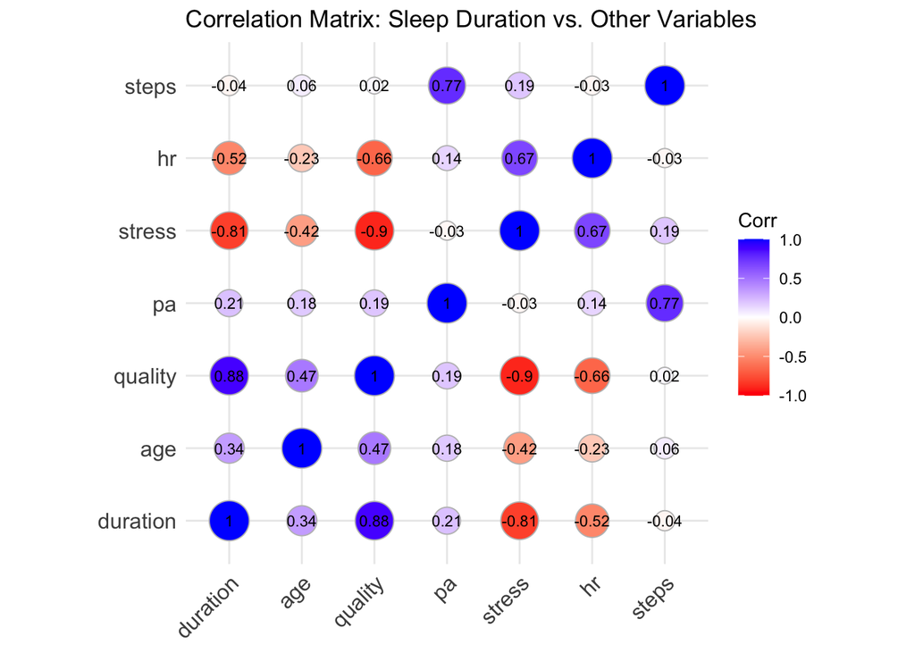

```r
# Plot correlation plot on continuous variables
library(ggcorrplot)
continuous_vars <- sleep2 %>%
    dplyr::select(duration, age, quality, pa, stress, hr, steps)

cor_matrix <- cor(continuous_vars, use = "complete.obs")

ggcorrplot(cor_matrix, lab = TRUE, lab_size = 3, method = "circle", colors = c("red",
    "white", "blue"), title = "Correlation Matrix: Sleep Duration vs. Other Variables")
```

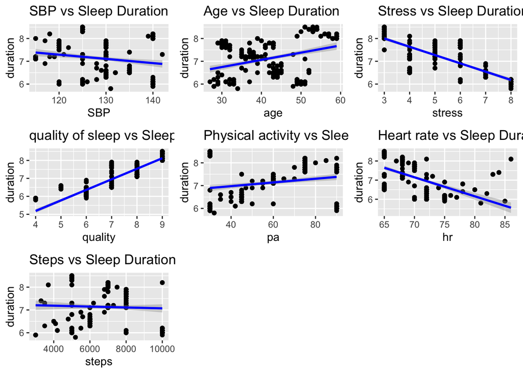

```r
# Plot the relationship of key variables with sleep duration
g1 <- ggplot(sleep2, aes(x = SBP, y = duration)) + geom_point() + geom_smooth(method = "lm",
    col = "blue") + labs(title = "SBP vs Sleep Duration")

g2 <- ggplot(sleep2, aes(x = age, y = duration)) + geom_point() + geom_smooth(method = "lm",
    col = "blue") + labs(title = "Age vs Sleep Duration")

g3 <- ggplot(sleep2, aes(x = gender_f, y = duration)) + geom_boxplot(fill = "lightblue",
    color = "black") + labs(title = "Gender vs Sleep Duration")

g4 <- ggplot(sleep2, aes(x = stress, y = duration)) + geom_point() + geom_smooth(method = "lm",
    col = "blue") + labs(title = "Stress vs Sleep Duration")

g5 <- ggplot(sleep2, aes(x = occup_f, y = duration)) + geom_boxplot(fill = "lightgreen",
    color = "black") + labs(title = "occupation vs Sleep Duration")

g6 <- ggplot(sleep2, aes(x = quality, y = duration)) + geom_point() + geom_smooth(method = "lm",
    col = "blue") + labs(title = "quality of sleep vs Sleep Duration")

g7 <- ggplot(sleep2, aes(x = pa, y = duration)) + geom_point() + geom_smooth(method = "lm",
    col = "blue") + labs(title = "Physical activity vs Sleep Duration")

g8 <- ggplot(sleep2, aes(x = bmi_f, y = duration)) + geom_boxplot(fill = "lightpink",
    color = "black") + labs(title = "BMI vs Sleep Duration")

g9 <- ggplot(sleep2, aes(x = hr, y = duration)) + geom_point() + geom_smooth(method = "lm",
    col = "blue") + labs(title = "Heart rate vs Sleep Duration")

g10 <- ggplot(sleep2, aes(x = steps, y = duration)) + geom_point() + geom_smooth(method = "lm",
    col = "blue") + labs(title = "Steps vs Sleep Duration")

g11 <- ggplot(sleep2, aes(x = disorder, y = duration)) + geom_boxplot(fill = "lightyellow",
    color = "black") + labs(title = "Sleep disorders vs Sleep Duration")

grid.arrange(g1, g2, g4, g6, g7, g9, g10, ncol = 3)
```

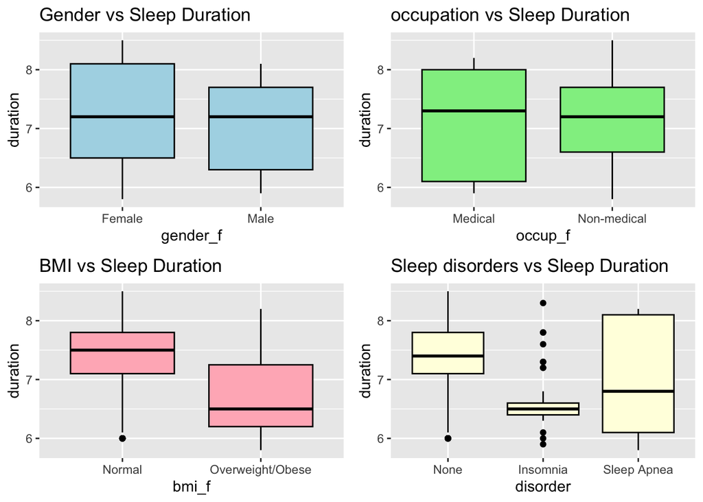

```r
grid.arrange(g3, g5, g8, g11, ncol = 2)
```

**Age:** Age shows a moderate positive correlation with sleep duration (0.34), suggesting that older individuals generally sleep a bit longer. However, the effect is relatively modest, indicating that age alone is not a strong determinant of sleep duration.

**Quality of Sleep:** Sleep quality is highly correlated with sleep duration (0.88). People who report better sleep quality also tend to sleep longer, which is expected since restful, uninterrupted sleep is typically associated with longer duration.

**Stress:** Stress demonstrates a strong negative correlation with sleep duration (-0.81). Higher stress levels are linked to shorter sleep, consistent with the understanding that stress can disrupt both the quality and quantity of sleep.

**Physical Activity (PA):** The correlation between physical activity and sleep duration is weak (0.21). While being more active may contribute to improved sleep, the relationship here is small, suggesting that other factors play a more important role.

**Heart Rate:** Resting heart rate has a moderate negative correlation with sleep duration (-0.52). Individuals with higher heart rates, possibly reflecting greater stress or cardiovascular strain, tend to sleep less.

**Steps:** Daily step counts are essentially unrelated to sleep duration (-0.04). This implies that overall daily movement, at least as measured by steps, does not directly affect how long people sleep.

**Gender:** No meaningful difference in sleep duration is observed between males and females.

**Occupation:** Participants with medical-related jobs sleep slightly longer than those in non-medical professions, which may reflect differences in lifestyle or stress exposure.

**BMI:** Individuals with normal BMI generally sleep longer than those classified as overweight or obese. This is consistent with evidence linking obesity to poorer sleep quality and conditions like Sleep Apnea.

**Sleep Disorders:** Sleep duration is longest among individuals without a sleep disorder. Those with Insomnia have the shortest duration, while people with Sleep Apnea tend to report longer sleep, though their rest is often fragmented or of lower quality.

### Linear regression

#### Full model

```r
lm <- lm(duration ~ SBP + gender_f + age + occup_f + quality + pa + stress + bmi_f +
    hr + steps + disorder, data = tr2)

summary(lm)
```

```
##
## Call:
## lm(formula = duration ~ SBP + gender_f + age + occup_f + quality +
##     pa + stress + bmi_f + hr + steps + disorder, data = tr2)
##
## Residuals:
##      Min       1Q   Median       3Q      Max
## -0.75548 -0.20187 -0.04329  0.16151  0.69749
##
## Coefficients:
##                         Estimate Std. Error t value Pr(>|t|)
## (Intercept)            7.381e+00  1.176e+00   6.275 2.69e-09 ***
## SBP                   -1.942e-02  5.747e-03  -3.380 0.000896 ***
## gender_fMale           3.685e-01  7.357e-02   5.010 1.33e-06 ***
## age                    3.546e-02  6.390e-03   5.550 1.05e-07 ***
## occup_fNon-medical    -1.690e-01  5.696e-02  -2.967 0.003429 **
## quality                1.314e-01  7.338e-02   1.790 0.075169 .
## pa                     7.707e-03  2.681e-03   2.875 0.004546 **
## stress                -2.591e-01  4.559e-02  -5.683 5.49e-08 ***
## bmi_fOverweight/Obese -4.202e-01  9.715e-02  -4.325 2.57e-05 ***
## hr                     1.915e-02  1.062e-02   1.804 0.073033 .
## steps                 -7.591e-05  3.382e-05  -2.245 0.026053 *
## disorderInsomnia      -4.902e-02  8.721e-02  -0.562 0.574769
## disorderSleep Apnea    6.160e-02  1.086e-01   0.567 0.571239
## ---
## Signif. codes:  0 '***' 0.001 '**' 0.01 '*' 0.05 '.' 0.1 ' ' 1
##
## Residual standard error: 0.3021 on 174 degrees of freedom
## Multiple R-squared:  0.871,  Adjusted R-squared:  0.8621
## F-statistic: 97.92 on 12 and 174 DF,  p-value: < 2.2e-16
```

#### Reduced model

```r
lm.reduced <- step(lm, direction = "both")
```

```
## Start:  AIC=-435.2
## duration ~ SBP + gender_f + age + occup_f + quality + pa + stress +
##     bmi_f + hr + steps + disorder
##
##            Df Sum of Sq    RSS     AIC
## - disorder  2   0.13934 16.015 -437.57
## <none>                  15.876 -435.20
## - quality   1   0.29239 16.168 -433.79
## - hr        1   0.29678 16.172 -433.74
## - steps     1   0.45969 16.335 -431.86
## - pa        1   0.75410 16.630 -428.52
## - occup_f   1   0.80329 16.679 -427.97
## - SBP       1   1.04219 16.918 -425.31
## - bmi_f     1   1.70658 17.582 -418.11
## - gender_f  1   2.28994 18.166 -412.00
## - age       1   2.81063 18.686 -406.72
## - stress    1   2.94629 18.822 -405.37
##
## Step:  AIC=-437.57
## duration ~ SBP + gender_f + age + occup_f + quality + pa + stress +
##     bmi_f + hr + steps
##
##            Df Sum of Sq    RSS     AIC
## <none>                  16.015 -437.57
## + disorder  2   0.13934 15.876 -435.20
## - steps     1   0.40109 16.416 -434.94
## - quality   1   0.42332 16.438 -434.69
## - hr        1   0.45424 16.469 -434.34
## - pa        1   0.73010 16.745 -431.23
## - SBP       1   1.05049 17.066 -427.69
## - occup_f   1   1.14957 17.165 -426.60
## - bmi_f     1   1.92881 17.944 -418.30
## - gender_f  1   2.31378 18.329 -414.33
## - age       1   2.74049 18.756 -410.03
## - stress    1   2.87956 18.895 -408.65
```

```r
summary(lm.reduced)
```

```
##
## Call:
## lm(formula = duration ~ SBP + gender_f + age + occup_f + quality +
##     pa + stress + bmi_f + hr + steps, data = tr2)
##
## Residuals:
##      Min       1Q   Median       3Q      Max
## -0.76480 -0.20490 -0.02924  0.14044  0.67130
##
## Coefficients:
##                         Estimate Std. Error t value Pr(>|t|)
## (Intercept)            6.870e+00  1.087e+00   6.319 2.09e-09 ***
## SBP                   -1.859e-02  5.471e-03  -3.398 0.000840 ***
## gender_fMale           3.502e-01  6.945e-02   5.043 1.14e-06 ***
## age                    3.484e-02  6.349e-03   5.488 1.40e-07 ***
## occup_fNon-medical    -1.916e-01  5.389e-02  -3.554 0.000487 ***
## quality                1.524e-01  7.068e-02   2.157 0.032371 *
## pa                     7.493e-03  2.645e-03   2.833 0.005156 **
## stress                -2.556e-01  4.544e-02  -5.625 7.16e-08 ***
## bmi_fOverweight/Obese -4.188e-01  9.097e-02  -4.604 7.91e-06 ***
## hr                     2.275e-02  1.018e-02   2.234 0.026725 *
## steps                 -6.994e-05  3.331e-05  -2.099 0.037201 *
## ---
## Signif. codes:  0 '***' 0.001 '**' 0.01 '*' 0.05 '.' 0.1 ' ' 1
##
## Residual standard error: 0.3017 on 176 degrees of freedom
## Multiple R-squared:  0.8699, Adjusted R-squared:  0.8625
## F-statistic: 117.7 on 10 and 176 DF,  p-value: < 2.2e-16
```

#### Reduced model justification

The final reduced model was obtained using stepwise selection, which combines forward and backward procedures to determine the most suitable set of predictors based on AIC.

The process began with a full model containing all candidate predictors. In the backward approach, variables were removed one at a time beginning with the least significant, and a variable was dropped if doing so improved or did not meaningfully worsen the model fit as measured by AIC. In the forward approach, predictors were introduced starting from none, and only those that significantly enhanced model fit were retained.

Decisions about including or excluding variables were guided by the Akaike Information Criterion (AIC), which balances model fit with parsimony. The algorithm stops once no further changes in variables improve AIC. Using this process, the stepwise procedure converged at an AIC of -437.57. The final model retained SBP, gender, age, occupation, sleep quality, physical activity, stress, BMI, heart rate, and steps, all of which were statistically significant with p-values below 0.05.

#### MSE in validation set

```r
anova(lm.reduced, lm)
```

```
## Analysis of Variance Table
##
## Model 1: duration ~ SBP + gender_f + age + occup_f + quality + pa + stress +
##     bmi_f + hr + steps
## Model 2: duration ~ SBP + gender_f + age + occup_f + quality + pa + stress +
##     bmi_f + hr + steps + disorder
##   Res.Df    RSS Df Sum of Sq      F Pr(>F)
## 1    176 16.015
## 2    174 15.876  2   0.13934 0.7636 0.4675
```

```r
pred.lm <- predict(lm.reduced, newdata = val2)
mse.lm.val <- mean((val2$duration - pred.lm)^2)
mse.lm.val
```

```
## [1] 0.07695689
```

Since the p-value is greater than 0.05, there is no significant difference between the two models. Therefore, it is more appropriate to retain the reduced model, as it achieves a similar fit with fewer covariates.

### KNN regression

```r
set.seed(12345)
mKnnReg <- function(trainDat, validDat, trainOut, validOut, k) {
    mseKNN <- rep(NA, times = length(k))
    for (i in 1:length(k)) {
        out <- FNN::knn.reg(train = trainDat, test = validDat, y = trainOut, k = k[i])
        mseKNN[i] <- mean((out$pred - validOut)^2)
    }
    return(mseKNN)
}

Kvec <- 1:30

mseKNN <- mKnnReg(trainDat = tr.z, validDat = val.z, trainOut = tr2$duration, validOut = val2$duration,
    k = Kvec)
mseKNN
```

```
##  [1] 0.01129032 0.01647849 0.01603345 0.01646505 0.01644731 0.01818399
##  [7] 0.01901690 0.01976310 0.01917563 0.01969032 0.02188128 0.02583259
## [13] 0.03183814 0.03865646 0.04459642 0.05009115 0.05802508 0.06494259
## [19] 0.07443809 0.08551505 0.09481506 0.10107438 0.11370409 0.12880656
## [25] 0.13728465 0.14325778 0.15293317 0.16261466 0.16807385 0.17552425
```

#### Optimal K justification

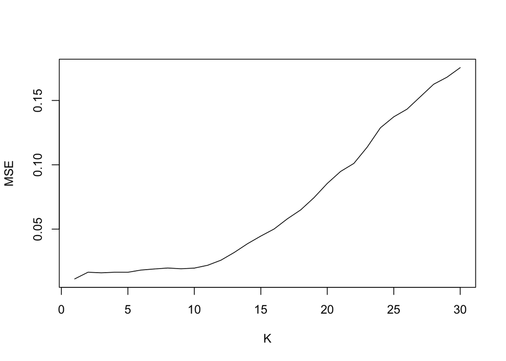

```r
plot(Kvec, mseKNN, type = "l", xlab = "K", ylab = "MSE")
```

```r
kopt <- which.min(mseKNN)
kopt
```

```
## [1] 1
```

The optimal value of k is 1, as this choice produces the lowest mean squared error (MSE).

#### Optimal K MSE

```r
final.knn <- knn.reg(train = tr.z, test = val.z, y = tr2$duration, k = kopt)
mse.knn.val <- mean((final.knn$pred - val2$duration)^2)
mse.knn.val
```

```
## [1] 0.01129032
```

### Final model selection

```r
which.min(c(mse.lm.val, mse.knn.val))
```

```
## [1] 2
```

**Comment:** After evaluating the models, I selected KNN as the final model because it achieved a lower MSE on the validation set compared to linear regression. A smaller MSE suggests that KNN provides more accurate predictions of sleep duration by reducing the gap between predicted and observed values. Furthermore, as a non-parametric method, KNN is able to capture complex, non-linear patterns in the data that linear regression may not fully account for.

### Interpretation

#### Predicting amount of sleep

```r
final.knn <- knn.reg(train = tr.val.z, test = test.z, y = tr.val2$duration, k = kopt)
summary(final.knn)
```

```
##           Length Class  Mode
## call       5     -none- call
## k          1     -none- numeric
## n          1     -none- numeric
## pred      94     -none- numeric
## residuals  0     -none- NULL
## PRESS      0     -none- NULL
## R2Pred     0     -none- NULL
```

```r
final.knn
```

```
## Prediction:
##  [1] 5.9 6.0 7.7 7.7 7.7 7.7 7.7 7.7 7.7 7.7 7.7 7.6 6.0 6.2 6.7 7.2 7.1 7.1 7.1
## [20] 6.2 7.8 7.4 7.2 7.2 7.2 7.1 7.3 7.1 7.1 7.1 7.2 6.9 7.2 7.2 7.2 7.2 7.1 7.6
## [39] 7.6 7.6 7.8 6.7 6.5 6.5 6.5 6.5 6.5 7.1 7.8 7.8 7.8 7.8 6.3 6.6 6.3 6.3 6.6
## [58] 6.6 6.3 6.6 6.3 6.3 6.4 6.5 6.0 6.1 6.1 6.1 8.1 6.0 6.0 6.0 6.0 6.0 6.0 6.0
## [77] 8.5 6.0 6.0 6.5 6.5 8.4 8.5 8.5 8.4 8.4 8.1 8.1 8.0 8.0 8.1 8.1 8.1 8.1
```

```r
mse.knn.test <- mean((final.knn$pred - test2$duration)^2)
mse.knn.test
```

```
## [1] 0.006276596
```

I used the combined training and validation set to build the final model, and then evaluated its performance on the testing set. The mean squared error (MSE) was calculated by comparing the model’s predicted values against the actual outcomes in the testing set.

I would select the KNN model. Compared to linear regression, KNN achieved a lower MSE on the validation set, indicating better predictive accuracy for sleep duration. Since the primary objective is to minimize prediction error, KNN is more suitable. Sleep duration is likely influenced by complex, non-linear interactions with factors such as stress, activity level, and BMI. KNN can capture these patterns without imposing a linear structure, making it more effective at modeling such relationships.

#### Sleep duration

##### Final model selected

```r
# Build a linear regression model with the selected predictors, trained on the
# combined training and validation dataset
final.lm <- lm(duration ~ SBP + gender_f + age + occup_f + pa + stress + bmi_f +
    hr, data = tr.val2)

summary(final.lm)
```

```
##
## Call:
## lm(formula = duration ~ SBP + gender_f + age + occup_f + pa +
##     stress + bmi_f + hr, data = tr.val2)
##
## Residuals:
##      Min       1Q   Median       3Q      Max
## -0.85810 -0.18374 -0.05385  0.16034  0.85140
##
## Coefficients:
##                        Estimate Std. Error t value Pr(>|t|)
## (Intercept)            7.001955   0.582124  12.028  < 2e-16 ***
## SBP                   -0.021447   0.004358  -4.922 1.49e-06 ***
## gender_fMale           0.476659   0.049997   9.534  < 2e-16 ***
## age                    0.045224   0.003821  11.835  < 2e-16 ***
## occup_fNon-medical    -0.221190   0.042604  -5.192 4.09e-07 ***
## pa                     0.003826   0.000934   4.096 5.56e-05 ***
## stress                -0.379434   0.016582 -22.882  < 2e-16 ***
## bmi_fOverweight/Obese -0.496207   0.061173  -8.112 1.75e-14 ***
## hr                     0.041325   0.006290   6.570 2.56e-10 ***
## ---
## Signif. codes:  0 '***' 0.001 '**' 0.01 '*' 0.05 '.' 0.1 ' ' 1
##
## Residual standard error: 0.2955 on 271 degrees of freedom
## Multiple R-squared:  0.869,  Adjusted R-squared:  0.8651
## F-statistic: 224.7 on 8 and 271 DF,  p-value: < 2.2e-16
```

```r
# Apply the model to the test set to generate predicted sleep duration values
predict.lm.test <- predict(final.lm, newdata = test2)
# Calculate the MSE on the test set to assess how well the model predicts sleep
# duration
mse.lm.test <- mean((predict.lm.test - test2$duration)^2)
mse.lm.test
```

```
## [1] 0.08171481
```

**Comment:** I selected the linear regression model. Compared to KNN, linear regression provides a simpler and more interpretable framework for understanding the data. Its coefficients clearly show the direction, strength, and significance of each predictor’s effect on sleep duration. This makes linear regression the preferred option when the primary goal is to explain how different factors influence sleep duration.

#### Explanation for a practitioner

In this analysis, I applied a linear regression model to predict sleep duration using predictors including systolic blood pressure (SBP), gender, age, occupation, physical activity, stress, BMI, and heart rate. The model was trained on the combined training and validation sets and then evaluated on the testing set.

The model showed strong performance, with a residual standard error of 0.2955 and an R-squared of 86.9%, which means it explained almost 87% of the differences in sleep duration among individuals. On the testing set, the model achieved an MSE of 0.082, indicating that the predicted values were very close to the actual sleep times and that the model can be considered accurate for practical use.

For individual predictors:

**SBP:** Each one-unit increase in systolic blood pressure is linked to a 0.02-hour reduction in sleep duration, reflecting a negative association.

**Gender:** On average, males sleep 0.48 hours longer than females, when holding other variables constant.

**Age:** Each additional year of age is associated with 0.05 more hours of sleep, suggesting older participants sleep slightly longer.

**Occupation:** Those in non-medical fields sleep 0.22 hours less than individuals in medical professions.

**Physical Activity:** Every extra minute of physical activity corresponds to an increase of 0.004 hours of sleep. Though small, this effect is statistically significant.

**Stress:** Stress exerts the strongest influence. Each one-unit rise in stress level decreases sleep duration by 0.38 hours, highlighting stress as a key factor reducing sleep.

**BMI:** Overweight or obese participants sleep 0.50 hours less than those with normal BMI.

**Heart Rate:** Each additional beat per minute in resting heart rate is linked to a 0.04-hour increase in sleep duration.